# 211-Discussion

Yu-Shiuan (Lily) Huang

Fall 2023

### Discussion I

For today’s discussion, we’ll first introduce **LaTeX** and **R Markdown**, which are two very useful typesetting systems for you to generate neat documents for your problem sets and research projects. The second part of discussion will review some basic R skills when exploring a new dataset.

#### 1. LaTeX

LaTeX is a high-quality typesetting system; it includes features designed for the production of technical and scientific documentation. LaTeX is the de facto standard for the communication and publication of scientific documents.

- Installation: [LaTeX installation guide](https://projects.iq.harvard.edu/files/gov2001/files/r_and_latex_installation.pdf)
- Short Tutorials: [LaTeX tutorial from Gov department PreFresher](https://projects.iq.harvard.edu/prefresher/additional-latex-resources)

If you prefer not to download the LaTeX compiler and editor to your laptop, you can use [Overleaf](https://www.overleaf.com/), which is an online LaTeX editor that is very easy to use and work on projects with multiple collaborators. It also provides many templates for you to choose from. Here is a brief [introduction video](https://www.youtube.com/watch?v=xcTN4F3l9Ds) of how to use Overleaf.

- To create a nice table output in Overleaf, [TablesGenerator](https://www.tablesgenerator.com/) is very helpful. You can also use `stargazer` in R to create regression tables in LaTeX form and copy them into Overleaf. Here is a [handout](https://ignacioriveros1.github.io/r/2021/03/25/stargazer-for-amazing-academic-tables.html) of how to use the `stargazer` package (we will talk more on this in the future).
- To insert math equations in Overleaf, [LaTeX Equation Editor](https://latex.codecogs.com/eqneditor/editor.php) would be your go-to.

Here is an [Overleaf template](https://www.overleaf.com/read/cddmfsytsxrz) for POL 211 Problem Set I. Please feel free to copy it to your future work!

#### 2. R Markdown

Another way to submit both your answers and R code with only one pdf document is by using **R Markdown**.

R Markdown is a markup language that allows you to create dynamic documents in R programming language. With R Markdown, you can easily combine text, code, and visualizations in a single document. R Markdown documents can be rendered in a variety of output formats, including HTML, PDF, Microsoft Word, and more.

R Markdown provides a way to weave together narrative text, code, and results into a single document that can be easily shared and reproduced. It allows you to write code and see the results of that code inline, making it easy to explain complex statistical analyses or data visualizations.

Here is a thorough introduction of [how to use R Markdown](https://rmarkdown.rstudio.com/lesson-1.html). For more information on how to adjust the style of your R Markdown, here is a [Cookbook](https://bookdown.org/yihui/rmarkdown-cookbook/).

For the following topic on exploring a new dataset using R, all the materials will be shown in R Markdown format. You are also more than welcome to upload your problem set:

- by knitting your R Markdown to **html** first, then open it in a browser, and then save it as a pdf.(Just click the `Knit` button!)
- by knitting your R Markdown to **pdf** directly if you have already downloaded a LaTeX compiler in your computer.

  When knitting to pdf, all of the contents in R Markdown will be presented in LaTeX format automatically. If you don’t have a LaTeX compiler installed on your machine, you will encounter an error message when attempting to knit your R Markdown to PDF. If you need more help, here is a [guide](https://www.youtube.com/watch?v=ETHo0O9_kvc) I found online that provides step-by-step instructions on how to do it.
- A R Markdown template for Problem Set I can be downloaded from Canvas-Files.

#### 3. Exploring a New Dataset using R (Part I)

Note: All these R codes are prepared by Prof. Ryan Hubert.

##### a. Load R packages

There are many useful packages in R that can be installed freely. If it is the first time you are going to use a package, here are the steps:

- Install it
- library it (which means telling R you are going to use it)

Once you have installed the package, you don’t have to install it every time you open R studio. However, you still have to load it through the `library` function every time.

```r
# Install packages
# install.packages("tidyverse") # manipulate data
# install.packages("Matrix") # calculate rank
## these are the packages we will use for today

# load packages
library(tidyverse)
library(Matrix)
```

The `tidyverse` is a powerful collection of R packages that are actually data tools for transforming and visualizing data. All packages of the `tidyverse` share an underlying philosophy and common APls.

[figure not shown]

Highly recommend this [data wrangling cheat sheet](https://www.rstudio.com/wp-content/uploads/2015/02/data-wrangling-cheatsheet.pdf) with `dplyr` and `tidyr` in R!

##### b. Import data

For today, we are using `USDC-DATASET-JOP.csv`. You can download this csv file from Canvas or from [here](https://dataverse.harvard.edu/file.xhtml?fileId=4306747&version=1.0.).

```r
# Import data
df <- read_csv("/Users/yu-shiuanhuang/Desktop/method-sequence/data/USDC-DATASET-JOP.csv")
# Here we assign the dataset as an object called “df”

## Note: you create new objects by assigning them with the `<-` phrase. You can also use an equal sign `=`.
```

Here are some tips for how to find the file path of the data you are going to use.

- First, where did you store your data? In which folder? In my case, I stored the data in the `data` folder within the `method-sequence` folder.
- Second, use `getwd` function to get the grasp of how does a file path look like. `getwd` function returns an absolute file path representing the current working directory of the R process.

```r
  getwd()
```

```
## [1] "/Users/yu-shiuanhuang/Desktop/method-sequence/docs"
```

As you can see, my current working directory is `"/Users/yu-shiuanhuang/Desktop/method-sequence/docs"`. Since I know that I stored the data in the `data` folder within the `method-sequence` folder, I can simply just change the file path to `"/Users/yu-shiuanhuang/Desktop/method-sequence/data/USDC-DATASET-JOP.csv"` and put it in the `read_csv` function so R knows where to read the file you want.

If you import the data successfully, you should be able to see df popping up in the environment section.

[figure not shown]

Sometimes the dataset we are interested in may be stored in a different form, such as `dta`, `spss`, `xlsx`, `rds`, `rdata`, etc. You can find the corresponded codes from [here](https://www.datafiles.samhsa.gov/get-help/format-specific-issues/how-do-i-read-data-r).

##### c. Basic information about the dataset

What is the size of the dataset?

```r
# the number of row is:
nrow(df)
```

```
## [1] 97725
```

How many observations (rows) and variables (columns) we have in the dataset?

```r
# the number of column is:
ncol(df)
```

```
## [1] 54
```

You can also use `dim` function to get the size of the dataset.

```r
dim(df)
```

```
## [1] 97725    54
```

```r
## this function gives you the number of rows and columns at the same time
```

The size of this dataset is 97,725 x 54.

What does the dataset actually look like?

If you want to just quickly see the first six rows to get a feel for what the dataset looks like:

```r
head(df)
```

```
## # A tibble: 6 × 54
##   file      OUTCOME jrepublican jpresident jid_anon jyears APPEAL judge_replaced
##   <chr>     <chr>         <dbl> <chr>         <dbl>  <dbl>  <dbl>          <dbl>
## 1 /dockets… jud_de…           1 Reagan        90059     13      0              0
## 2 /dockets… dism_o…           1 Reagan        90048      9      0              0
## 3 /dockets… dism_p…           1 Reagan        90012     11      0              0
## 4 /dockets… dism_o…           1 Bush41        90016      3      0              0
## 5 /dockets… dism_v…           1 Reagan        90096     10      0              0
## 6 /dockets… dism_v…           1 Reagan        90158     11      0              0
## # ℹ 46 more variables: jsenior <dbl>, court <chr>, division <dbl>, YEAR <dbl>,
## #   QUARTER <chr>, nature_of_suit <dbl>, SECTION <chr>, ORIGIN <dbl>,
## #   JURIS <chr>, jury_demand <chr>, PROSE <dbl>, COUNTY <chr>, pla_count <dbl>,
## #   pla_count_prose <dbl>, pla_count_anonymous <dbl>, pla_count_IND <dbl>,
## #   pla_count_BUS <dbl>, pla_count_GOV <dbl>, pla_count_LAW <dbl>,
## #   pla_count_OTH <dbl>, pla_count_repeat <dbl>, pla_acount <dbl>,
## #   pla_acount_repeat <dbl>, def_count <dbl>, def_count_prose <dbl>, …
```

Note that a lot of the variables are not visible because R will try to clean up output.

One convenient thing is that you can see the type of each variable.[Here](https://tibble.tidyverse.org/articles/types.html) is the full list of all the possible types of variables (in tidyverse).

If you want to look at the whole dataset, use `View(df)` command and it will open in a new tab in R.

##### d. Exploring the variables

Most people prefer to look at variables using their names.

How to ask R to tell us the name of each variables?

```r
# Name of each column
colnames(df)
```

```
##  [1] "file"                "OUTCOME"             "jrepublican"
##  [4] "jpresident"          "jid_anon"            "jyears"
##  [7] "APPEAL"              "judge_replaced"      "jsenior"
## [10] "court"               "division"            "YEAR"
## [13] "QUARTER"             "nature_of_suit"      "SECTION"
## [16] "ORIGIN"              "JURIS"               "jury_demand"
## [19] "PROSE"               "COUNTY"              "pla_count"
## [22] "pla_count_prose"     "pla_count_anonymous" "pla_count_IND"
## [25] "pla_count_BUS"       "pla_count_GOV"       "pla_count_LAW"
## [28] "pla_count_OTH"       "pla_count_repeat"    "pla_acount"
## [31] "pla_acount_repeat"   "def_count"           "def_count_prose"
## [34] "def_count_anonymous" "def_count_IND"       "def_count_BUS"
## [37] "def_count_GOV"       "def_count_LAW"       "def_count_OTH"
## [40] "def_count_repeat"    "def_acount"          "def_acount_repeat"
## [43] "oth_count"           "oth_count_prose"     "oth_count_anonymous"
## [46] "oth_count_IND"       "oth_count_BUS"       "oth_count_GOV"
## [49] "oth_count_LAW"       "oth_count_OTH"       "oth_count_repeat"
## [52] "oth_acount"          "oth_acount_repeat"   "ifp_denial"
```

How to call out one specific variable we are interested in from the dataset? There are multiple ways to look at an arbitrary variable:

```r
## Use column number
df[, 2]
df[[2]]

## Use variable name
df[, "OUTCOME"]
df[["OUTCOME"]]
df$OUTCOME ## This is the most common way to do it
```

```r
head(df$OUTCOME) ## To see the first six rows of this variable
```

```
## [1] "jud_default_plaintiff" "dism_other"            "dism_pros"
## [4] "dism_other"            "dism_vol"              "dism_vol"
```

What kind of variable is the `OUTCOME` variable? It looks like a categorical variable!

The next question would be what are the categories (called “levels” in R) of this variable?

```r
# This asks R to give us a list of all the values used in this variable.
unique(df$OUTCOME)
```

```
##  [1] "jud_default_plaintiff"  "dism_other"             "dism_pros"
##  [4] "dism_vol"               "settlement"             "jud_motion_defendant"
##  [7] "dism_juris"             "remand"                 "jud_misc_NA"
## [10] "jud_misc_both"          "jud_motion_plaintiff"   "jud_misc_defendant"
## [13] "jud_jury_defendant"     "transfer"               "jud_bench_defendant"
## [16] "jud_misc_plaintiff"     "jud_consent_plaintiff"  "jud_jury_plaintiff"
## [19] "jud_default_both"       "jud_motion_both"        "jud_default_defendant"
## [22] "jud_bench_plaintiff"    "jud_jury_both"          "jud_consent_both"
## [25] "jud_bench_both"         "jud_directed_defendant" "jud_consent_defendant"
## [28] "jud_motion_NA"          "jud_jury_NA"            "jud_bench_NA"
## [31] "jud_consent_NA"         "jud_directed_plaintiff" "jud_default_NA"
## [34] "jud_directed_NA"
```

There are 34 categories in this variable.

Here’s an issue: when R loaded the dataset, it didn’t code this variable as a categorical variable. Since the `OUTCOME` variable is coded as strings/texts in the dataset, in R, the type of this variable is character.

```r
# Look at what this says about the variable type:
type_sum(df$OUTCOME)
```

```
## [1] "chr"
```

```r
# When you summarize it in R, R doesn’t provide you with meaningful information
summary(df$OUTCOME)
```

```
##    Length     Class      Mode
##     97725 character character
```

Good news is that we can transform the type of a variable in R.

```r
# lets's change the type to a categorical variable, known as a "factor" variable in R:
df$OUTCOME <- as.factor(df$OUTCOME)
## In order to override the original variable, we have to assign the new version of the variable to the original one.

# After factorizing, R can summarize in a more meaningful way: what is the number of each category?
summary(df$OUTCOME)
```

```
##             dism_juris             dism_other              dism_pros
##                   1321                  16198                   3123
##               dism_vol         jud_bench_both    jud_bench_defendant
##                  17805                     10                    192
##           jud_bench_NA    jud_bench_plaintiff       jud_consent_both
##                     22                    110                    199
##  jud_consent_defendant         jud_consent_NA  jud_consent_plaintiff
##                     48                     93                    391
##       jud_default_both  jud_default_defendant         jud_default_NA
##                      5                     69                      7
##  jud_default_plaintiff jud_directed_defendant        jud_directed_NA
##                    228                     34                      1
## jud_directed_plaintiff          jud_jury_both     jud_jury_defendant
##                      6                     73                   1260
##            jud_jury_NA     jud_jury_plaintiff          jud_misc_both
##                    121                    528                    399
##     jud_misc_defendant            jud_misc_NA     jud_misc_plaintiff
##                   1355                   2239                    413
##        jud_motion_both   jud_motion_defendant          jud_motion_NA
##                    428                  10510                    821
##   jud_motion_plaintiff                 remand             settlement
##                    629                   4546                  32627
##               transfer
##                   1914
```

##### e. Exploring the observations

Each row (observation) in this dataset is a court case. We can also use R to look at an arbitrary one.

```r
df[5,] # This means that we want to call out the fifth row of the data.
```

```
## # A tibble: 1 × 54
##   file      OUTCOME jrepublican jpresident jid_anon jyears APPEAL judge_replaced
##   <chr>     <fct>         <dbl> <chr>         <dbl>  <dbl>  <dbl>          <dbl>
## 1 /dockets… dism_v…           1 Reagan        90096     10      0              0
## # ℹ 46 more variables: jsenior <dbl>, court <chr>, division <dbl>, YEAR <dbl>,
## #   QUARTER <chr>, nature_of_suit <dbl>, SECTION <chr>, ORIGIN <dbl>,
## #   JURIS <chr>, jury_demand <chr>, PROSE <dbl>, COUNTY <chr>, pla_count <dbl>,
## #   pla_count_prose <dbl>, pla_count_anonymous <dbl>, pla_count_IND <dbl>,
## #   pla_count_BUS <dbl>, pla_count_GOV <dbl>, pla_count_LAW <dbl>,
## #   pla_count_OTH <dbl>, pla_count_repeat <dbl>, pla_acount <dbl>,
## #   pla_acount_repeat <dbl>, def_count <dbl>, def_count_prose <dbl>, …
```

```r
# If you want to see all the variables for that observation, here are some options:
t(df[5,]) ## downside: this treats all the values like strings!
```

```
##                     [,1]
## file                "/dockets-cacd/1995/199501-00068.html"
## OUTCOME             "dism_vol"
## jrepublican         "1"
## jpresident          "Reagan"
## jid_anon            "90096"
## jyears              "10"
## APPEAL              "0"
## judge_replaced      "0"
## jsenior             "0"
## court               "cacd"
## division            "2"
## YEAR                "1995"
## QUARTER             "1995Q1"
## nature_of_suit      "442"
## SECTION             "1983"
## ORIGIN              "1"
## JURIS               "federal_question"
## jury_demand         "Plaintiff"
## PROSE               NA
## COUNTY              "06037"
## pla_count           "1"
## pla_count_prose     "0"
## pla_count_anonymous "0"
## pla_count_IND       "0.7538"
## pla_count_BUS       "0.1453"
## pla_count_GOV       "0.0485"
## pla_count_LAW       "0.0315"
## pla_count_OTH       "0.021"
## pla_count_repeat    "0"
## pla_acount          "1"
## pla_acount_repeat   "1"
## def_count           "4"
## def_count_prose     "0"
## def_count_anonymous "1"
## def_count_IND       "2.7986"
## def_count_BUS       "0.7653"
## def_count_GOV       "0.2055"
## def_count_LAW       "0.1402"
## def_count_OTH       "0.0903"
## def_count_repeat    "1"
## def_acount          "0"
## def_acount_repeat   "0"
## oth_count           "0"
## oth_count_prose     "0"
## oth_count_anonymous "0"
## oth_count_IND       "0"
## oth_count_BUS       "0"
## oth_count_GOV       "0"
## oth_count_LAW       "0"
## oth_count_OTH       "0"
## oth_count_repeat    "0"
## oth_acount          "0"
## oth_acount_repeat   "0"
## ifp_denial          "0"
```

```r
as.data.frame(df[5,]) ## downside: sort of ugly and hard to see
```

```
##                                   file  OUTCOME jrepublican jpresident jid_anon
## 1 /dockets-cacd/1995/199501-00068.html dism_vol           1     Reagan    90096
##   jyears APPEAL judge_replaced jsenior court division YEAR QUARTER
## 1     10      0              0       0  cacd        2 1995  1995Q1
##   nature_of_suit SECTION ORIGIN            JURIS jury_demand PROSE COUNTY
## 1            442    1983      1 federal_question   Plaintiff    NA  06037
##   pla_count pla_count_prose pla_count_anonymous pla_count_IND pla_count_BUS
## 1         1               0                   0        0.7538        0.1453
##   pla_count_GOV pla_count_LAW pla_count_OTH pla_count_repeat pla_acount
## 1        0.0485        0.0315         0.021                0          1
##   pla_acount_repeat def_count def_count_prose def_count_anonymous def_count_IND
## 1                 1         4               0                   1        2.7986
##   def_count_BUS def_count_GOV def_count_LAW def_count_OTH def_count_repeat
## 1        0.7653        0.2055        0.1402        0.0903                1
##   def_acount def_acount_repeat oth_count oth_count_prose oth_count_anonymous
## 1          0                 0         0               0                   0
##   oth_count_IND oth_count_BUS oth_count_GOV oth_count_LAW oth_count_OTH
## 1             0             0             0             0             0
##   oth_count_repeat oth_acount oth_acount_repeat ifp_denial
## 1                0          0                 0          0
```

```r
## To draw out an element from a data, you have to specify a row number and a column number.
df[5, 1]
```

```
## # A tibble: 1 × 1
##   file
##   <chr>
## 1 /dockets-cacd/1995/199501-00068.html
```

Usually, you only need to see some of the variables. For example: suppose we want to know which judge heard this case (`jid_anon`), what the case outcome was (`OUTCOME`) and the party of the judge’s appointing president (`jrepublican`).

```r
df[5, c("jid_anon", "OUTCOME", "jrepublican")]
```

```
## # A tibble: 1 × 3
##   jid_anon OUTCOME  jrepublican
##      <dbl> <fct>          <dbl>
## 1    90096 dism_vol           1
```

A more neat way to write the code by using `tidyverse` package.

```r
# using pipes to do the same thing; use select function from tidyverse to pick variables
df[5, ] %>% select(jid_anon, OUTCOME, jrepublican)
```

```
## # A tibble: 1 × 3
##   jid_anon OUTCOME  jrepublican
##      <dbl> <fct>          <dbl>
## 1    90096 dism_vol           1
```

`%>%` is called “pipes.” Pipes take the output from one function and feed it to the first argument of the next function.

We can also find a row by “filtering” the data based on some criteria.

What if I want to find a case by its ID number? Eg, “/dockets-cacd/2007/200738-00195.html”

```r
# use filter function from tidyverse to set the condition
df %>% filter(file == "/dockets-cacd/2007/200738-00195.html")
```

```
## # A tibble: 1 × 54
##   file      OUTCOME jrepublican jpresident jid_anon jyears APPEAL judge_replaced
##   <chr>     <fct>         <dbl> <chr>         <dbl>  <dbl>  <dbl>          <dbl>
## 1 /dockets… settle…           1 Bush43        90104      0      0              0
## # ℹ 46 more variables: jsenior <dbl>, court <chr>, division <dbl>, YEAR <dbl>,
## #   QUARTER <chr>, nature_of_suit <dbl>, SECTION <chr>, ORIGIN <dbl>,
## #   JURIS <chr>, jury_demand <chr>, PROSE <dbl>, COUNTY <chr>, pla_count <dbl>,
## #   pla_count_prose <dbl>, pla_count_anonymous <dbl>, pla_count_IND <dbl>,
## #   pla_count_BUS <dbl>, pla_count_GOV <dbl>, pla_count_LAW <dbl>,
## #   pla_count_OTH <dbl>, pla_count_repeat <dbl>, pla_acount <dbl>,
## #   pla_acount_repeat <dbl>, def_count <dbl>, def_count_prose <dbl>, …
```

What if I want to find all cases heard by judges appointed by Bush 43?

```r
df %>% filter(jpresident == "Bush43")
```

```
## # A tibble: 17,622 × 54
##    file     OUTCOME jrepublican jpresident jid_anon jyears APPEAL judge_replaced
##    <chr>    <fct>         <dbl> <chr>         <dbl>  <dbl>  <dbl>          <dbl>
##  1 /docket… jud_mo…           1 Bush43        90131      1      0              0
##  2 /docket… dism_v…           1 Bush43        90131      0      0              0
##  3 /docket… dism_p…           1 Bush43        90131      0      0              0
##  4 /docket… dism_j…           1 Bush43        90131      0      0              0
##  5 /docket… dism_o…           1 Bush43        90159      0      0              0
##  6 /docket… dism_p…           1 Bush43        90159      0      0              0
##  7 /docket… dism_o…           1 Bush43        90159      0      0              0
##  8 /docket… dism_o…           1 Bush43        90159      0      0              0
##  9 /docket… dism_o…           1 Bush43        90131      0      1              0
## 10 /docket… dism_o…           1 Bush43        90159      0      1              1
## # ℹ 17,612 more rows
## # ℹ 46 more variables: jsenior <dbl>, court <chr>, division <dbl>, YEAR <dbl>,
## #   QUARTER <chr>, nature_of_suit <dbl>, SECTION <chr>, ORIGIN <dbl>,
## #   JURIS <chr>, jury_demand <chr>, PROSE <dbl>, COUNTY <chr>, pla_count <dbl>,
## #   pla_count_prose <dbl>, pla_count_anonymous <dbl>, pla_count_IND <dbl>,
## #   pla_count_BUS <dbl>, pla_count_GOV <dbl>, pla_count_LAW <dbl>,
## #   pla_count_OTH <dbl>, pla_count_repeat <dbl>, pla_acount <dbl>, …
```

The reason why we need to add quotation mark when setting the condition in the `filter` function is that both of the `file` and `jpresident` variables are coded in character type (categorical) in R. If we filter our cases based on whether the judge of the case is assigned by a Republican president (when `jrepublican` == 1), we don’t have to add quotation mark in the condition as this variable is coded as the type of double (dbl) in R, which is a class of numeric.

```r
df %>% filter(jrepublican == 1)
```

```
## # A tibble: 42,679 × 54
##    file     OUTCOME jrepublican jpresident jid_anon jyears APPEAL judge_replaced
##    <chr>    <fct>         <dbl> <chr>         <dbl>  <dbl>  <dbl>          <dbl>
##  1 /docket… jud_de…           1 Reagan        90059     13      0              0
##  2 /docket… dism_o…           1 Reagan        90048      9      0              0
##  3 /docket… dism_p…           1 Reagan        90012     11      0              0
##  4 /docket… dism_o…           1 Bush41        90016      3      0              0
##  5 /docket… dism_v…           1 Reagan        90096     10      0              0
##  6 /docket… dism_v…           1 Reagan        90158     11      0              0
##  7 /docket… settle…           1 Reagan        90158     11      0              0
##  8 /docket… settle…           1 Ford          90218     19      0              0
##  9 /docket… jud_mo…           1 Nixon         90148     24      0              0
## 10 /docket… dism_j…           1 Reagan        90005     13      0              0
## # ℹ 42,669 more rows
## # ℹ 46 more variables: jsenior <dbl>, court <chr>, division <dbl>, YEAR <dbl>,
## #   QUARTER <chr>, nature_of_suit <dbl>, SECTION <chr>, ORIGIN <dbl>,
## #   JURIS <chr>, jury_demand <chr>, PROSE <dbl>, COUNTY <chr>, pla_count <dbl>,
## #   pla_count_prose <dbl>, pla_count_anonymous <dbl>, pla_count_IND <dbl>,
## #   pla_count_BUS <dbl>, pla_count_GOV <dbl>, pla_count_LAW <dbl>,
## #   pla_count_OTH <dbl>, pla_count_repeat <dbl>, pla_acount <dbl>, …
```

##### f. Some measurement issues

What kinds of variable do we have?

There are slight differences between the way a computer stores/understands data and the way we conceptualize it. In this dataset, we have some variables on cardinal scales.

For example: How many plaintiffs are named in each case? (Why is this on a cardinal scale?)

```r
head(df$pla_count)
```

```
## [1] 1 1 1 1 1 1
```

What is the data type? It’s “dbl” which means it’s a number that need not be an integer (can be fractional number, 3.51)

```r
type_sum(df$pla_count)
```

```
## [1] "dbl"
```

Note: this variable is actually comprised of integers, we could convert it if we want, but this doesn’t really matter. (Why? 11.0 = 11)

```r
df$pla_count <- as.integer(df$pla_count)
type_sum(df$pla_count)
```

```
## [1] "int"
```

We also have some variables that are ordinal.

For example, in what years were cases filed? (Why is this on an ordinal scale?)

```r
head(df$YEAR)
```

```
## [1] 1995 1995 1995 1995 1995 1995
```

What is the data type? It’s also “dbl”.

```r
type_sum(df$YEAR)
```

```
## [1] "dbl"
```

Acknowledge, this is bad! We do not want R to treat this as a cardinal variable.

For example, it (incorrectly) allows us to add them:

```r
df$YEAR[1] + df$YEAR[2]
```

```
## [1] 3990
```

```r
## Notice here the change in indexing! Remember that when you call out one variable from the data, it is a vector. To draw out an element from a vector, you only have to specify one number inside [ ].
```

So, we should change it to a factor variable so that we don’t make this mistake.

```r
df$YEAR <- as.factor(df$YEAR)
df$YEAR[1] + df$YEAR[2]
```

```
## [1] NA
```

We got an error when we tried to do something silly, which is good!

In the analysis for Ryan’s paper, they had to convert the `OUTCOME` variable to dummies. How can we do it in R?

Recall that there are 34 unique categories in the `OUTCOME` variable.

```r
unique(df$OUTCOME)
```

```
##  [1] jud_default_plaintiff  dism_other             dism_pros
##  [4] dism_vol               settlement             jud_motion_defendant
##  [7] dism_juris             remand                 jud_misc_NA
## [10] jud_misc_both          jud_motion_plaintiff   jud_misc_defendant
## [13] jud_jury_defendant     transfer               jud_bench_defendant
## [16] jud_misc_plaintiff     jud_consent_plaintiff  jud_jury_plaintiff
## [19] jud_default_both       jud_motion_both        jud_default_defendant
## [22] jud_bench_plaintiff    jud_jury_both          jud_consent_both
## [25] jud_bench_both         jud_directed_defendant jud_consent_defendant
## [28] jud_motion_NA          jud_jury_NA            jud_bench_NA
## [31] jud_consent_NA         jud_directed_plaintiff jud_default_NA
## [34] jud_directed_NA
## 34 Levels: dism_juris dism_other dism_pros dism_vol ... transfer
```

When we want to make each category of this variable into dummies, it means that we need to create 34 new dummy variables (34 new columns for the dataset). For example, the new dummy variable `dism_other` will be coded as 1 if the `OUTCOME` variable is coded as dism_other. Let’s use `ifesle` function to create this dummy!

```r
df$dism_other <- ifelse(df$OUTCOME == "dism_other", 1, 0)
```

Let’s check if we did it correctly.

```r
df %>% select(OUTCOME, dism_other) %>% head()
```

```
## # A tibble: 6 × 2
##   OUTCOME               dism_other
##   <fct>                      <dbl>
## 1 jud_default_plaintiff          0
## 2 dism_other                     1
## 3 dism_pros                      0
## 4 dism_other                     1
## 5 dism_vol                       0
## 6 dism_vol                       0
```

But there is a total of 34 categories in the `OUTCOME` variable, it would be a waste of time to generate all 34 dummies if we have to retype the above one by one for each category. Luckily, R is here to help us! We can run a `forloop` function to ask R to do the same thing for all the 34 categories.

```r
for(v in levels(df$OUTCOME)){
  print(v)
  df[[v]] <- ifelse(df$OUTCOME == v, 1, 0) ## df[[v]] is a way to call out/create a variable
} ## This is called "forloop."
```

```
## [1] "dism_juris"
## [1] "dism_other"
## [1] "dism_pros"
## [1] "dism_vol"
## [1] "jud_bench_both"
## [1] "jud_bench_defendant"
## [1] "jud_bench_NA"
## [1] "jud_bench_plaintiff"
## [1] "jud_consent_both"
## [1] "jud_consent_defendant"
## [1] "jud_consent_NA"
## [1] "jud_consent_plaintiff"
## [1] "jud_default_both"
## [1] "jud_default_defendant"
## [1] "jud_default_NA"
```

[output cut: 19 more lines]

```r
ncol(df)
```

```
## [1] 88
```

You can find that the number of columns increased to 88 from 54 after creating 34 dummies.

##### g. The rank of a matrix

The rank of a dataset is the number of “linearly independent” variables.

```r
library(Matrix) ## This package has a function for calculating the rank of a matrix

# Let's create a fake dataset
df2 <- data.frame(var1 = seq(1, 100, 3)) ## Creates 34 rows

df2$var2 <- (df2$var1/pi) ## create a new variable called var2 in df2
pi ## pi is an inbuilt R constant whose value is 3.141593
```

```
## [1] 3.141593
```

```r
df2$var3 <- 6
df2
```

```
##    var1       var2 var3
## 1     1  0.3183099    6
## 2     4  1.2732395    6
## 3     7  2.2281692    6
## 4    10  3.1830989    6
## 5    13  4.1380285    6
## 6    16  5.0929582    6
## 7    19  6.0478878    6
## 8    22  7.0028175    6
## 9    25  7.9577472    6
## 10   28  8.9126768    6
## 11   31  9.8676065    6
## 12   34 10.8225361    6
## 13   37 11.7774658    6
## 14   40 12.7323954    6
```

[output cut: 20 more lines]

What is the rank of this matrix (the fake dataset we created)?

```r
rankMatrix(as.matrix(df2))
```

```
## [1] 2
## attr(,"method")
## [1] "tolNorm2"
## attr(,"useGrad")
## [1] FALSE
## attr(,"tol")
## [1] 7.549517e-15
```

```r
## The input must be a numeric matrix, which means we have to covert df2 from a dataframe to a matrix
```

There are 3 variables in df2, but there are only 2 linearly independent variables since the generation of var2 is based on var1.

### Discussion II

For today’s discussion, we’ll first briefly go over the solution keys to Problem Set 1 and then continue our materials for exploring a new dataset using R.

#### 1. Solution Keys to Problem Set 1

##### Question 1 (4 points)

Load the `dbj.csv` file.

- What is the unit of observation in the data set?

  **Answer: The unit of analysis in the data set is per judge.**

  You can also double check this answer by using the `unique()` on the `name` variable to see if the number of observations is equal to the number of categories in that variable.

  ```r
  library(tidyverse)

  dbj <- read_csv("/Users/yu-shiuanhuang/Desktop/method-sequence/data/dbj.csv")  ## you can also use read.csv

  length(unique(dbj$name)) == nrow(dbj)
  ```

  ```
  ## [1] TRUE
  ```

  Doing this helps us confirm that this dataset is structured around the information of individual judges. However, it’s worth considering that the dataset might be organized by judicial cases, where one judge could be associated with multiple cases. In such a scenario, the unit of analysis wouldn’t be per judge but per case.
- How many judges are there in the data set, and how many variables does the data set have?

  **Answer: There are 224 judges and 12 variables in the data set.**

  ```r
  ## Number of judges
  nrow(dbj) ## this is just the number of observations
  ```

  ```
  ## [1] 224
  ```

  ```r
  ## Number of variables
  ncol(dbj)
  ```

  ```
  ## [1] 12
  ```

- How many judges in the data set have children? To answer this, first create a new binary (or “dummy”) variable that is equal to 1 if a judge has any children, and 0 otherwise.

  ```r
  ## Judges with children (using a new dummy variable)
  dbj <- dbj %>%
    mutate(has_children = ifelse(child > 0, 1, 0))

  dbj_c <- dbj %>%
    count(has_children)

  knitr::kable(dbj_c, "simple", align = "cc",
           col.names = c("Has Children or Not", "Number of Judges"))
  ```

  | Has Children or Not | Number of Judges |
  | --- | --- |
  | 0 | 25 |
  | 1 | 199 |

- Of the judges that have children, what percentage has female children? To calculate this number, first create a new binary (or “dummy”) variable that is equal to 1 if a judge has female children, and 0 otherwise.

  **Answer: Among the judges who have children, approximately 81.41% of them have female children.**

  ```r
  ## Share of judges with children that have female children
  ## First, create dummy
  dbj <- dbj %>%
    mutate(has_female_children = ifelse(girls > 0, 1, 0))

  ## We need the average of "has_female_children" conditional on "has_children" equal to 1
  dbj_with_children <- dbj %>%
    filter(has_children == 1)

  mean(dbj_with_children$has_female_children)
  ```

  ```
  ## [1] 0.8140704
  ```

##### Question 2 (4 points)

Our outcome in this exercise will be the proportion of pro-feminist decisions, `progressive.vote`.

First, calculate the mean, median and standard deviation of this variable (across all judges).

**Answer:**

```r
## Summary stats for progressive.vote
mean(dbj$progressive.vote)
```

```
## [1] 0.4340902
```

```r
median(dbj$progressive.vote)
```

```
## [1] 0.422619
```

```r
sd(dbj$progressive.vote)
```

```
## [1] 0.2489341
```

Next, we want to assess differences between groups. Create a new factor variable that takes on separate values for each of the four groups (Republican men/women, Democratic men/women) defined by gender and partisanship. The variable should be a “factor” or “character” type variable in R - you can use string labels such as `Dem_Male`, `Dem_Female`, etc. It should **not** be a numeric variable.

Having created this variable, now create a **boxplot** that summarizes the propensity to decide in a pro-feminist way by group, in one plot. Briefly discuss the results – what does the boxplot show, and what does this tell us about differences between groups? Are partisan differences larger than gender differences, or the other way around? A brief answer is sufficient here.

**Answer: The plot shows that progressive decisions are more prevalent among Democratic judges than among Republican judges. Gender differences are less pronounced than partisan differences, since within parties, male and female judges have similar average proportions of pro-feminist decisions.**

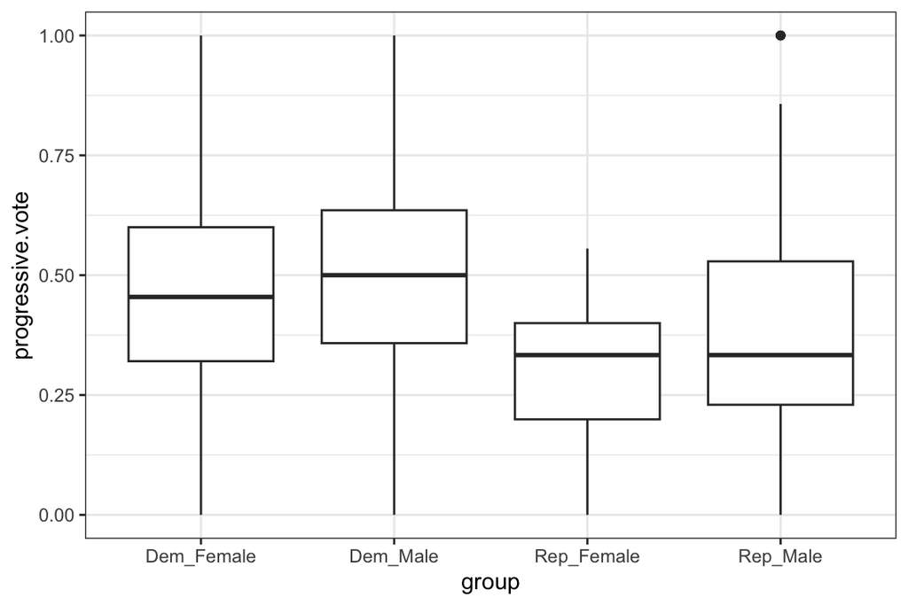

```r
## Create new variable
dbj <- dbj %>%
  mutate(group = case_when(republican == 1 & woman == 1 ~ "Rep_Female",
                           republican == 0 & woman == 1 ~ "Dem_Female",
                           republican == 1 & woman == 0 ~ "Rep_Male",
                           republican == 0 & woman == 0 ~ "Dem_Male"))

## Use ggplot to plot the average by group
ggplot(dbj, aes(x = group, y = progressive.vote)) +
  geom_boxplot() +
  theme_bw()
```

You can enhance the boxplot by including additional information, such as displaying the median of the progressive vote for each group.

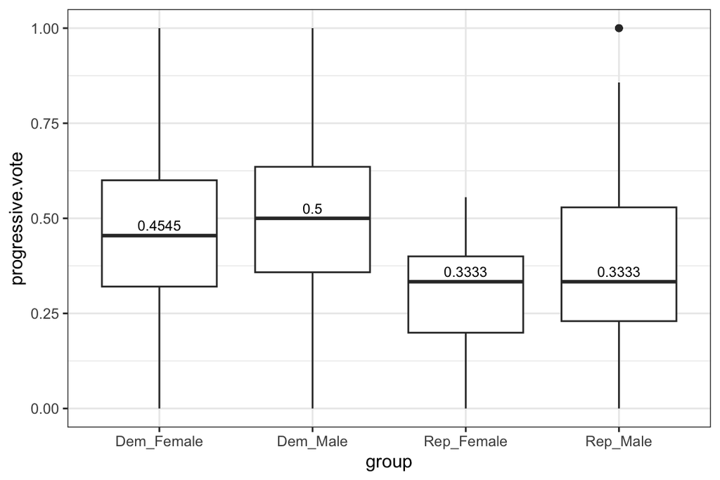

```r
## Calculate median for each group
dbj_md <- dbj %>%
  group_by(group) %>%
  summarise(MD = median(progressive.vote))

## Use ggplot to plot the average by group with median for each group
ggplot(data = dbj, aes(x = group, y = progressive.vote)) +
  geom_boxplot() +
  geom_text(data = dbj_md, aes(group, MD, label = round(MD, 4)),
            position = position_dodge(width = 0.8),
            size = 3, vjust = -0.5) +
  theme_bw()
```

##### Question 3 (2 points)

From before, we have a new binary variable which takes a value of `1` if a judge has *at least* one child (that is, any children at all), and `0` otherwise.

Use this variable to answer the following questions.

- Are Republicans and Democrats equally likely to be parents (that is, have at least one child)?

  ```r
  ## First question: average likelihood of having kids among D and R
  df <- dbj %>%
    group_by(republican) %>%
    summarise(mean(has_children))

  knitr::kable(df, "simple", align = "cc",
           col.names = c("Republican",
                         "Average Likelihood of Having Kids"))
  ```

  | Republican | Average Likelihood of Having Kids |
  | --- | --- |
  | 0 | 0.8834951 |
  | 1 | 0.8925620 |

- Do judges with children vote differently on feminist issues than judges without? If so, how are they different?

  **Answer: It does not appear as if there are large differences in pro-feminist voting when comparing judges with and without children. Among judges without children, 46% voted in favor of pro-feminist issues, slightly higher than the 43% of judges with children who voted for pro-feminist issues.**

  ```r
  ## Next question: voting behavior conditional on having children
  df <- dbj %>%
    group_by(has_children) %>%
    summarise(mean(progressive.vote))

  knitr::kable(df, "simple", align = "cc",
           col.names = c("Has Children",
                         "Average Likelihood of Voting Pro-feminist Issues"))
  ```

  | Has Children | Average Likelihood of Voting Pro-feminist Issues |
  | --- | --- |
  | 0 | 0.4560773 |
  | 1 | 0.4313280 |

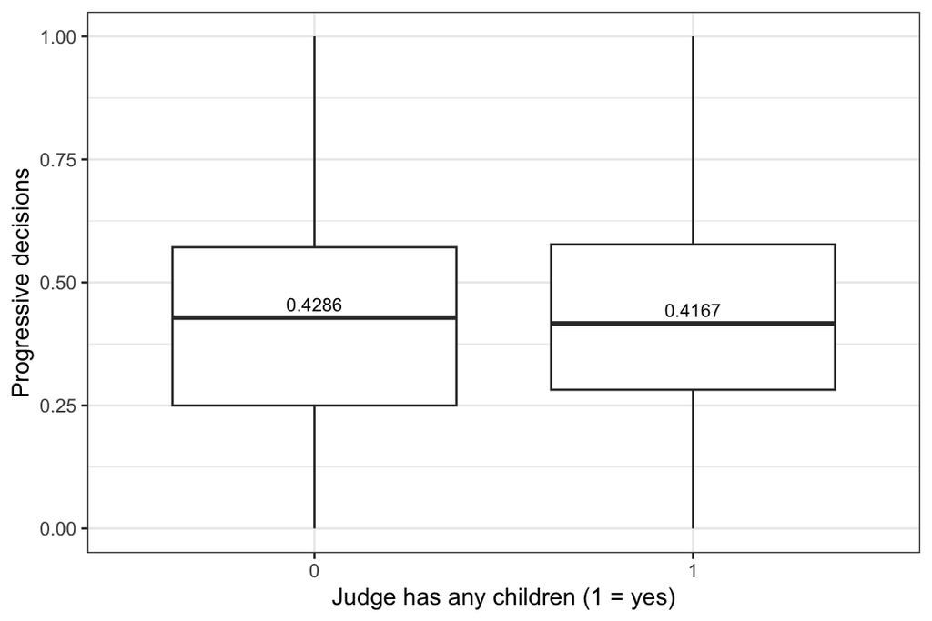

  ```r
  ## We can also again use a boxplot for this

  ## Calculate median for each group
  dbj_hc_md <- dbj %>%
    group_by(has_children) %>%
    summarise(MD = median(progressive.vote))

  ggplot(dbj, aes(factor(has_children), progressive.vote)) +
    geom_boxplot() +
    geom_text(data = dbj_hc_md, aes(factor(has_children), MD,
                                label = round(MD, 4)),
          position = position_dodge(width = 0.8),
          size = 3, vjust = -0.5) +
    xlab("Judge has any children (1 = yes)") +
    ylab("Progressive decisions") +
    theme_bw()
  ```

##### Question 4 (2 points)

Please evaluate the following statements. For each statement, indicate whether you believe the statement makes sense or not. If it does not, please provide a short motivation.

1. The judge’s religion can be described as an ordinal variable.

   **Answer: Incorrect: higher values do not indicator higher ranks, since the variable does not measure a concept that is ordered.**
2. A colleague argues that the judge’s religion may be an important predictor of judges’ decisions – more religious judges may decide differently than less religious judges. Therefore, your colleague recommends splitting the `religion` variable (see definition above) into two groups: the set of judges for which `religion` is greater than 10, and the set of judges for which it is 10 or lower. Then, your colleague recommends comparing the mean proportion of pro-feminist decisions in each of the two groups.

   **Answer: This does not make sense - splitting the variable in this way tells us nothing about the whether a judge is more or less religious. The variable (although it is coded as a numeric variable in the data set) is actually categorical, and only tells us which religious denomination a judge belongs to. There is actually no variable in the data that measure whether judges are more or less religious.**
3. A colleague comments that the data set is ambiguous, since there is no variable that measures whether a judge was appointed by a Democratic president.

   **Answer: This does not make sense. Since judges can only be appointed by Republican or Democratic presidents, having a single binary variable (`republican`) is sufficient.**

##### Additional question (required for students in the methods subfield)

##### Question 5 (3 points)

What is the difference in the proportion of pro-feminist decisions between judges who have at least one daughter and those who do not have any? Compute this difference in two ways; (1) using any judge who has children, (2) separately for judges that have one, two, or three children. For (2), you should end with three estimates: one for the judges with one child, one for the judges with two children, and one for the judges with three children (HINT: you will subset the data quite a few times to achieve this).

- Compute the difference (1) using any judge who has children.

  **Answer: The difference in the proportion of pro-feminist decisions between judges who have at least one daughter and those who do not have any is about 11%.**

  |  | **`has_female_children == 1`** | **`has_female_children == 0`** |
  | --- | --- | --- |
  | **`has_children == 1`** | `mean(progressive.vote)` | `mean(progressive.vote)` |
  | **`has_children == 0`** | `mean(progressive.vote)` | `mean(progressive.vote)` |

  ```r
  dbj %>%
    filter(has_children == 1) %>%
    group_by(has_female_children) %>%
    summarise(mean_prog = mean(progressive.vote)) %>%
    summarise(diff = mean_prog[has_female_children == 1] -
            mean_prog[has_female_children == 0])
  ```

  ```
  ## # A tibble: 1 × 1
  ##    diff
  ##   <dbl>
  ## 1 0.110
  ```

- Compute the difference (2) separately for judges that have one, two, or three children.

  **Answer: Among judges who have at least one child, two children, and three children, the difference in the proportion of pro-feminist decisions between those who have at least one daughter and those who do not have any is about 24%, 8%, and 19%, respectively.**

  |  | **`has_female_children == 1`** | **`has_female_children == 0`** |
  | --- | --- | --- |
  | **`child == 1`** | `mean(progressive.vote)` | `mean(progressive.vote)` |
  | **`child == 2`** | `mean(progressive.vote)` | `mean(progressive.vote)` |
  | **`child == 3`** | `mean(progressive.vote)` | `mean(progressive.vote)` |

  ```r
  diff_list <- dbj %>%
    filter(child %in% c(1,2,3)) %>%  ## Subset to people w/ 1,2,3 children
    group_by(has_female_children, child) %>%
    summarise(mean_prog = mean(progressive.vote)) %>%  ## Average
    ungroup() %>%
    group_by(child) %>%  ## Calculate differences by no. of children
    summarise(diff = mean_prog[has_female_children == 1] -
            mean_prog[has_female_children == 0])

  knitr::kable(diff_list, "simple", align = "cc",
           col.names = c("Has no. Children", "Difference"))
  ```

  | Has no. Children | Difference |
  | --- | --- |
  | 1 | 0.2408984 |
  | 2 | 0.0847949 |
  | 3 | 0.1893141 |

#### 2. Exploring a New Dataset using R (Part II)

For today, we are using `USDC-DATASET-JOP.csv`. You can download this csv file from Canvas or from [here](https://dataverse.harvard.edu/file.xhtml?fileId=4306747&version=1.0.)

```r
## Load packages
library(tidyverse)

## Import data
df <- read_csv("/Users/yu-shiuanhuang/Desktop/method-sequence/data/USDC-DATASET-JOP.csv")
```

##### a. Summary Statistics

In the following, we will compute summary statistics for the univariate distribution of the variable that quantifies the number of defendants named in each court case (it’s named `def_count`).

1. Calculate the mean

   ```r
   ## This is the easy way to calculate the mean:
   mean(df$def_count, na.rm = TRUE)
   ```

   ```
   ## [1] 4.184753
   ```

   ```r
   ## How to calculate it in the long/manual way?
   ## Try out!
   sum(df$def_count)/nrow(df)
   ```

   ```
   ## [1] 4.184753
   ```

   Recall the sample mean equation from the lecture slide:

   $$\bar{x} =
   \frac{1}{N}\sum_{i=1}^{N}x_{i}=\frac{x_{1}+x_{2}+...+x_{N}}{N}$$
2. Calculate the median

   ```r
   ## This is the easy way to calculate the median:
   median(df$def_count, na.rm = TRUE)
   ```

   ```
   ## [1] 3
   ```

   ```r
   ## How to calculate it in the long/manual way?
   ## Try out!
   ## First, sort the distribution from smallest to largest values
   sorted.def_count <- sort(df$def_count)


   ## Next, identify the "middle" value, which is (N+1)/2
   sorted.def_count[(nrow(df)+1)/2]
   ```

   ```
   ## [1] 3
   ```

   Since the distribution of `def_count` has an odd number, we have one median. If instead we had an even number, notice that R will automatically take **the average of the two middle values**. Technically, as Gailmard (2014) points out, any number weakly between the two middle values is a median.

   ```r
   fake.data <- c(3, 0, 2, 10, 7, 1) ## notice: even number of values!

   sort(fake.data)
   ```

   ```
   ## [1]  0  1  2  3  7 10
   ```

   ```r
   median(fake.data)
   ```

   ```
   ## [1] 2.5
   ```

   R tells us the median is 2.5 but technically it’s any number on interval $[2, 3]$.
3. Calculate the variance and standard deviation

   ```r
   ## This is the easy way to calculate the variance and std. dev.:
   var(df$def_count, na.rm = TRUE)
   ```

   ```
   ## [1] 62.53998
   ```

   ```r
   sd(df$def_count, na.rm = TRUE)
   ```

   ```
   ## [1] 7.908222
   ```

   ```r
   ## How to calculate them in the long/manual way?
   ## Try out!
   ## Sample variance
   sum((df$def_count-mean(df$def_count))^2)/(nrow(df)-1)
   ```

   ```
   ## [1] 62.53998
   ```

   ```r
   ## Sample standard deviation
   sqrt(sum((df$def_count-mean(df$def_count))^2)/(nrow(df)-1))
   ```

   ```
   ## [1] 7.908222
   ```

   Recall the sample variance equation from the lecturer slide:

   $$s^2_{x}=\frac{1}{N-1}\sum_{i=1}^{N}(x_i-\bar{x})^2$$

Now that you know how to manually compute the sample mean, median, variance, and standard deviation in R, let’s create a custom `function` that can calculate these four descriptive statistics all at once, without relying on the built-in R functions like `mean()`, `median()`, `var()`, or `sd()`.

Please manually create a function named `des_stat` by using `function()`:

```r
## Create your own function
## Try out!

des_stat <- function(x){
  x <- x[!is.na(x)] ## remove missing values from x
  s.mean <- sum(x)/length(x) ## sample mean
  s.median <- sort(x)[(length(x)+1)/2] ## sample median
  s.variance <- sum((x-mean(x))^2)/(length(x)-1) ## sample variance
  s.sd <- sqrt(s.variance)

  ## design the function to return these values
  stats <- data.frame(mean = s.mean,
                      median = s.median,
                      variance = s.variance,
                      sd = s.sd)
  stats
}

des_stat(df$def_count)
```

```
##       mean median variance       sd
## 1 4.184753      3 62.53998 7.908222
```

How to create a function in R?

While applying built-in functions facilitates many common tasks, often we need to create our own function to automate the performance of a particular task. To declare a user-defined function in R, we use the keyword `function`. The syntax is as follows:

```r
function_name <- function(parameters){
  function_body
}
```

Above, the main components of an R function are: **function name**, **function parameters**, and **function_body**. Let’s take a look at each of them separately.

- **function name**: This is the name of the function object that will be stored in the R environment after the function definition and used for calling that function. It should be concise but clear and meaningful so that the user who reads our code can easily understand what exactly this function does.
- **function parameters**: Sometimes, they are called formal **arguments**. Function parameters are the variables in the function definition placed inside the parentheses and separated with a comma that will be set to actual values (called arguments) each time we call the function.
- **function_body**: The function body is a set of commands inside the curly braces that are run in a predefined order every time we call the function. In other words, in the function body, we place what exactly we need the function to do.

For example:

```r
circumference <- function(r){
  2*pi*r
}

circumference(2)
```

```
## [1] 12.56637
```

Above, we created a function to calculate the circumference of a circle with a known radius using the formula $C=2\pi r$, so the function has the only parameter `r`. After defining the function, we called it with the radius equal to 2 (hence, with the argument 2). The function body we set will do the calculation for us (i.e., $2*\pi*2$).

Here is an example when you have more than 1 parameter (argument) in your function:

```r
sum_two_nums <- function(x, y){
    x + y
}
sum_two_nums(1, 2)
```

```
## [1] 3
```

```r
sum_two_nums(pi, 5)
```

```
## [1] 8.141593
```

4. Calculate the interquartile range (IQR)

   The $n$th percentile is the value in a distribution where $n$ percent of the values are equal to or below that value. IQR is defined by the difference between the first and the third quartile.

   $$IQR = P^{75} - P^{25}$$

   ```r
   ## This is the easy way to find the first and the third quartile:
   quantile(df$def_count, 0.25) ## First quartile
   ```

   ```
   ## 25%
   ##   2
   ```

   ```r
   quantile(df$def_count, 0.75) ## Third quartile
   ```

   ```
   ## 75%
   ##   5
   ```

   ```r
   ## You can also use quantile function to find an arbitrary percentile
   quantile(df$def_count, 0.87) ## the 87th percentile
   ```

   ```
   ## 87%
   ##   7
   ```

   ```r
   ## Notice: R names the values it returns. That's helpful, but sometimes annoying.
   ## Remove the name this way:
   unname(quantile(df$def_count, 0.25))
   ```

   ```
   ## [1] 2
   ```

   ```r
   unname(quantile(df$def_count, 0.75))
   ```

   ```
   ## [1] 5
   ```

   ```r
   ## This is the easy way to calculate IQR:
   IQR(df$def_count)
   ```

   ```
   ## [1] 3
   ```

   ```r
   ## This is a longer way:
   unname(quantile(df$def_count, 0.75)) - unname(quantile(df$def_count, 0.25))
   ```

   ```
   ## [1] 3
   ```

   ```r
   ## How to calculate IQR in the long/manual way (similar to the median)?

   ## First, sort the distribution from smallest to largest values
   sorted.def_count <- sort(df$def_count)


   ## Next, identify the value at the 25th percentile: 0.25 * N (round this up to nearest integer using ceiling function)
   sorted.def_count[ceiling(0.25*nrow(df))]
   ```

   ```
   ## [1] 2
   ```

   ```r
   sorted.def_count[ceiling(0.75*nrow(df))]
   ```

   ```
   ## [1] 5
   ```

5. Find outliers

   An arbitrary (but widely used) definition of an outlier is that any value in a distribution that is at least $1.5×IQR$ above the third quartile or below the first quartile.

   How many outliers are there in the distribution of `def_count`?

   ```r
   ## First, what is the lowest and highest threshold for outliers?
   iqr.d <- IQR(df$def_count)
   min.threshold <- quantile(df$def_count, 0.25) - (1.5 * iqr.d)
   min.threshold ## -2.5
   ```

   ```
   ##  25%
   ## -2.5
   ```

   ```r
   max.threshold <- quantile(df$def_count, 0.75) + (1.5 * iqr.d)
   max.threshold ## 9.5
   ```

   ```
   ## 75%
   ## 9.5
   ```

   Any data point that is smaller than -2.5 or larger than 9.5 is an outlier.

   ```r
   ## Please count how many outliers are there in the distribution of def_count?
   ## Try out!
   df %>% filter(def_acount < min.threshold | def_count > max.threshold) %>% count()
   ```

   ```
   ## # A tibble: 1 × 1
   ##       n
   ##   <int>
   ## 1  7267
   ```

##### b. Plot distribution (histograms)

To better observe the distribution of a variable, plot histograms! Histograms visualize quantitative data or numerical data (cardinal variables).

```r
## First, we would like to define the bins that will be used later
my.min.value <- min(df$def_count) ## Find the minimum of the variable
my.max.value <- max(df$def_count) ## Find the maximum of the variable

my.bins <- seq(my.min.value, my.max.value, 1)
## Generate a sequence of number that the values are from the minimum to the maximum while the increment of the sequence is 1
```

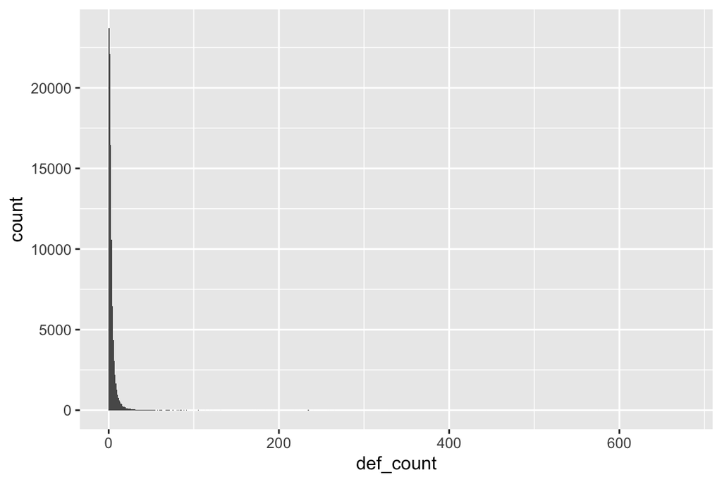

```r
# Now, let's build a plot layer by layer:
ggplot(df) +
  geom_histogram(aes(x = def_count), breaks = my.bins)
```

This histogram sucks! Why? Because it’s not easy to see the most important part of the distribution (the low values). In other words: we’re plotting a lot of outliers.

Let’s try to focus in on the part of the plot that’s the most interesting. To do this, we need to exclude outliers from the data and only plot any values that are not outliers!

```r
## Remember: we already figured out what the outliers are:
outliers <- df$def_count[df$def_count < min.threshold | df$def_count > max.threshold]
unique(sort(outliers))
```

```
##   [1]  10  11  12  13  14  15  16  17  18  19  20  21  22  23  24  25  26  27
##  [19]  28  29  30  31  32  33  34  35  36  37  38  39  40  41  42  43  44  45
##  [37]  46  47  48  49  50  51  52  53  54  55  56  57  58  59  60  61  62  63
##  [55]  65  66  67  68  69  70  71  72  73  75  76  77  80  81  82  83  84  85
##  [73]  86  87  89  90  92  94  95  97  98 100 101 102 103 105 106 107 109 111
##  [91] 114 115 118 119 122 123 124 132 139 151 162 169 174 178 181 184 185 191
## [109] 193 199 202 219 220 225 230 232 234 235 236 237 239 241 258 260 266 271
## [127] 279 330 445 475 510 576 676
```

Looks like any number 10 or above is an outlier.

```r
## So, let's tell R to only plot a histogram for values 9 and lower.
my.max.value <- 9

## Let's make the x axis numbers correspond to the bins.
## To do this, let's define what we want our labels to be:
my.labs <- seq(my.min.value, my.max.value, 1)
```

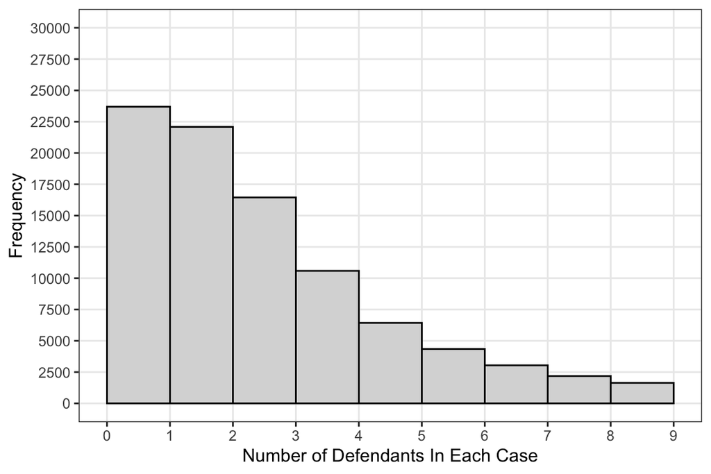

```r
ggplot2::ggplot(data = df, aes(x = def_count)) +
  geom_histogram(breaks = my.bins, color = "black", fill = "gray85") +
  scale_x_continuous(limits = c(my.min.value, my.max.value), breaks = my.labs) +
  scale_y_continuous(breaks = seq(0,30000,2500), limits = c(0,30000)) +
  labs(x = "Number of Defendants In Each Case", y = "Frequency") +
  theme_bw() +
  theme(panel.grid.minor = element_blank())
```

We can also manually check the exact frequency of each bar to see if 0 is excluded from the 0-1 bar.

```r
df %>% count(def_count)
```

```
## # A tibble: 143 × 2
##    def_count     n
##        <dbl> <int>
##  1         0    67
##  2         1 23629
##  3         2 22086
##  4         3 16450
##  5         4 10585
##  6         5  6431
##  7         6  4344
##  8         7  3041
##  9         8  2185
## 10         9  1640
## # ℹ 133 more rows
```

We can also add vertical lines that specify mean and median of the variable.

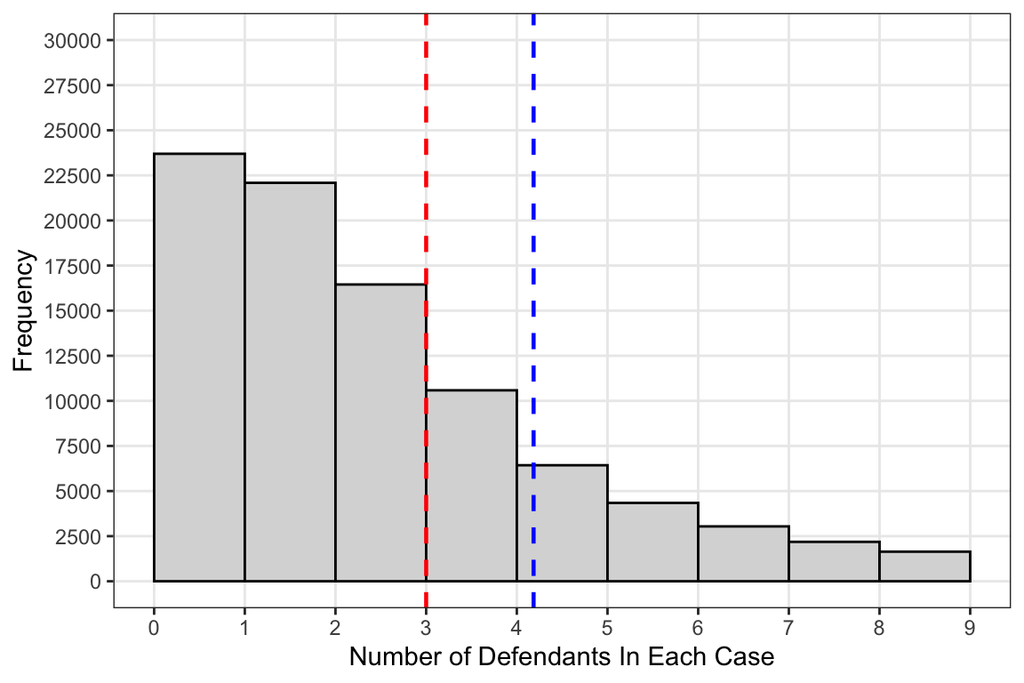

```r
# Let's save the mean and median as objects that we can use later.
my.mean <- mean(df$def_count)
my.median <- median(df$def_count)

ggplot(df, aes(x = def_count)) +
  geom_histogram(breaks = my.bins, color = "black", fill = "gray85") +
  scale_x_continuous(limits = c(my.min.value, my.max.value), breaks = my.labs) +
  scale_y_continuous(breaks = seq(0,30000,2500), limits = c(0,30000)) +
  geom_vline(aes(xintercept = my.mean), size = 0.8, linetype = 2, color = "blue") +
  ## add the line of mean
  geom_vline(aes(xintercept = my.median), size = 0.8, linetype = 2, color = "red") +
  ## add the line of median
  labs(x = "Number of Defendants In Each Case", y = "Frequency") +
  theme_bw() +
  theme(panel.grid.minor = element_blank())
```

We can see that the distribution of `def_count` is **right skewed**, which is also referred to positively skewed. What does this mean?

A skewed distribution occurs when one tail is longer than the other. Skewness defines the asymmetry of a distribution. Unlike the familiar normal distribution with its bell-shaped curve, these distributions are asymmetric. The two halves of the distribution are not mirror images because the data are not distributed equally on both sides of the distribution’s peak.

How to Tell if a Distribution is Left Skewed or Right Skewed?

- **Right skewed** distributions occur when the long tail is on the right side of the distribution. Analysts also refer to them as positively skewed. This condition occurs because probabilities taper off more slowly for higher values. Consequently, you’ll find extreme values far from the peak on the high end more frequently than on the low. When the distribution of data is skewed to the right, *the mean is often larger than the median*.
- **Left skewed** distributions occur when the long tail is on the left side of the distribution. Statisticians also refer to them as negatively skewed. This condition occurs because probabilities taper off more slowly for lower values. Therefore, you’ll find extreme values far from the peak on the low side more frequently than the high side. When the distribution of data is skewed to the right, *the median is often greater than the mean*.

How you plot frequency is important!

What if I wanted to use different bin sizes?

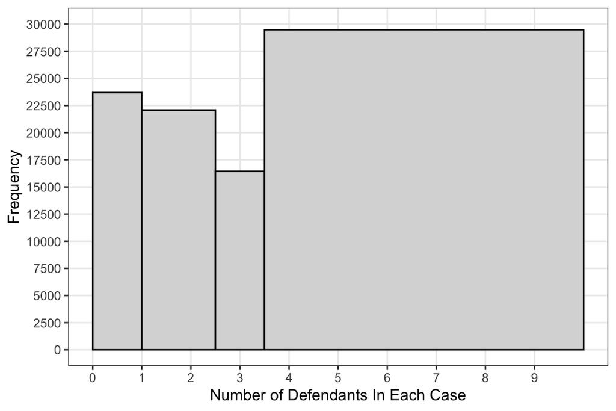

```r
my.bins2 <- c(0,1,2.5,3.5,10)

ggplot(df, aes(x = def_count)) +
  geom_histogram(breaks = my.bins2, color = "black", fill = "gray85") +
  scale_x_continuous(breaks = my.labs) +
  scale_y_continuous(breaks = seq(0,30000,2500), limits = c(0,30000)) +
  labs(x = "Number of Defendants In Each Case", y = "Frequency") +
  theme_bw() +
  theme(panel.grid.minor = element_blank())
```

This feels like it’s misleading, because it is!

Let’s fix it by using density on the y axis. Density is relative frequency per unit on the x axis. The density of each bin is calculated by dividing its relative frequency by its width in terms of units of the x variable (i.e., you divide the frequency of a group by the width of it).

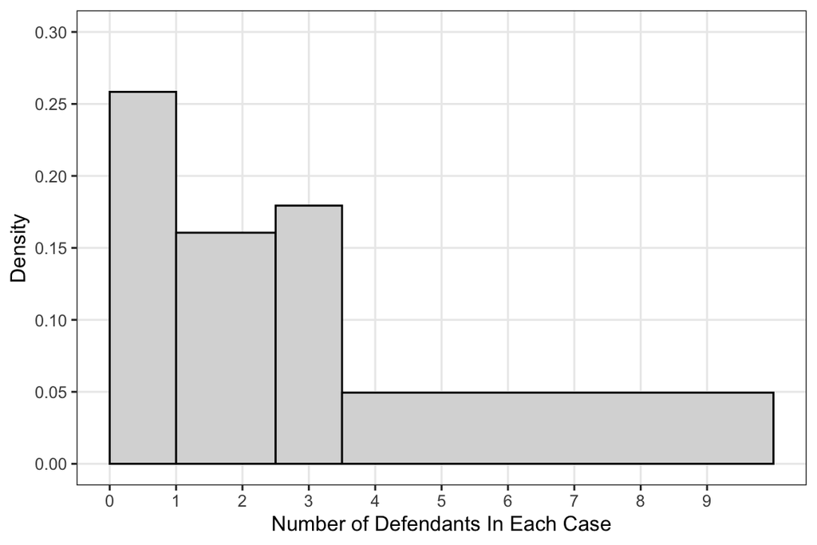

```r
ggplot(df) +
  geom_histogram(aes(y = ..density.., x = def_count), breaks = my.bins2,
                 color = "black", fill = "gray85") +
  scale_x_continuous(breaks = my.labs) +
  scale_y_continuous(breaks = seq(0,0.3,0.05), limits = c(0,0.3)) +
  labs(x = "Number of Defendants In Each Case", y = "Density") +
  theme_bw() +
  theme(panel.grid.minor = element_blank())
```

### Discussion III

For today’s discussion, we’ll begin by reviewing the solution keys for Problem Set 2. Afterward, we’ll delve into the topic of exploring relationships in data. We will learn how to use R to visualize relationships between two variables, whether they are categorical or numerical. Additionally, we will explore statistics that help us formally describe these relationships.

#### 1. Solution Keys to Problem Set 2

##### Question 1 (2 points)

Creating descriptive statistics is a key part of any research project. We will work with data compiled by Raj Chetty and coauthors. The paper is here: https://www.nber.org/papers/w23618. Alternatively, you can also read a summary report here: https://opportunityinsights.org/wp-content/uploads/2018/03/coll_mrc_summary.pdf). The purpose of this data is measure the role of colleges in facilitating upward (economic) mobility.

1. In the report, the authors define a measure called “Mobility Rate”, which is defined as the product of “Access” and “Success Rate”. Provide brief definitions of “Access” and “Success Rate”. Then, provide a brief explanation why using either one of these two measures separately may not be sufficient to measure how much each college contributes to upward mobility.

   **Answer:**

   **Access is defined as the fraction of students at a given college who come from families in the bottom 20% of the income distribution. Success rate is defined as the fraction of students at a given college who reach the top 20% of the income distribution. Using either one of these measures separately may not be sufficient to measure how much each college contributes to upward mobility, since colleges with a high access rate may not necessarily have a high success rate, and vice versa.**
2. Recall that studies can be classified as descriptive, causal or measurement. For each of these three categories, please state (i) whether the paper falls in that category and (ii) why or why not it can be grouped in that category.

   **Answer:**

   **Descriptive and measurement. The study does not answer the question of whether some characteristic of colleges causes some colleges to be more successful than others. The abstract actually states that “Although our descriptive analysis does not identify colleges’ causal effects on students’ outcomes, the publicly available statistics constructed here highlight colleges that deserve further study as potential engines of upward mobility.”**

##### Question 2 (4 points)

The next questions focus on the variables `par_median` and `mr_kq5_pq1`, which are the median income of parents of students at a given college and its mobility rate, respectively.

1. Calculate the mean, median, standard deviation and interquartile range of `par_median`. Briefly interpret the difference between the mean and the median – what does it tell you about the distribution of `par_median`?

   **Answer:**

   **The mean, median, standard deviation, and IQR of `par_median` are as follows: 93145.96, 89100, 29085.32, and 29200, respectively. Notably, the mean of `par_median` is higher than the median, indicating that the distribution of `par_median` is right-skewed, and the possibility of outliers existing in the right tail should be considered.**

   ```r
   ## load packages and import data
   library(tidyverse)

   df <- read.csv("/Users/yu-shiuanhuang/Desktop/method-sequence/data/chetty_data.csv")
   ```

   ```r
   ## Mean
   mean(df$par_median)
   ```

   ```
   ## [1] 93145.96
   ```

   ```r
   ## Median
   median(df$par_median)
   ```

   ```
   ## [1] 89100
   ```

   ```r
   ## SD
   sd(df$par_median)
   ```

   ```
   ## [1] 29085.32
   ```

   ```r
   ## IQR
   IQR(df$par_median)
   ```

   ```
   ## [1] 29200
   ```

2. Create two histograms of `par_median`, one with 10 bins, and one with 50 bins. Do you find one of them more informative?

   **Answer:**

   **The histogram with 50 bins provides more detailed information and is more informative. Having too few bins, as in the histogram with 10 bins, can obscure important patterns in the data. The 50-bin histogram is particularly useful for pinpointing the distribution of outliers in `par_median`, offering a more precise depiction compared to the 10-bin histogram, which may not effectively reveal their locations.**

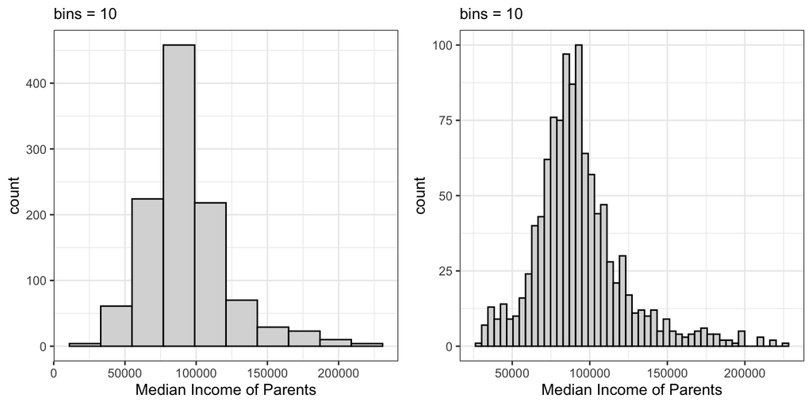

   ```r
   p1 <- ggplot(df, aes(par_median)) +
     geom_histogram(bins = 10, color = "black", fill = "gray85") +
     labs(x = "Median Income of Parents", subtitle = "bins = 10") +
     theme_bw()

   ggpubr::ggarrange(p1, p2, ncol = 2, nrow = 1)
   ```

3. Next, create two histograms, with any number of bins, for public and private colleges separately. Note that you should do this in one plot. You can use the `facet_wrap` function.

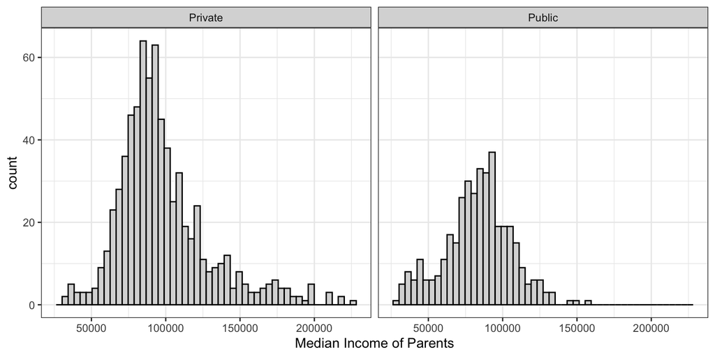

   ```r
   ggplot(df, aes(par_median)) +
     geom_histogram(bins = 50, color = "black", fill = "gray85") +
     labs(x = "Median Income of Parents") +
     facet_wrap(~ public) +
     theme_bw()
   ```

4. Next, an education policymaker is interested in comparing mobility rates (see question 1.1) across states. The variable is called `mr_kq5_pq1`. In particular, the policymaker is interested in the median mobility rates, as well as mobility rates at the 80th percentile, for each state separately. Calculate these quantities by state. Next, you should create two plots. The first, should show the median mobility rate by state. The second should show the mobility rate at the 80th percentile by state. In each plot, you should only provide a single quantity for each state.
   - Ideally, these would be ranked by mobility rates, such that the order of the points in each plot is either ascending or descending. However, this is not strictly required for this problem set. You can use the `fct_reorder` function to reorder the states by the median mobility rate.
   - For readability, it makes the most sense to put the state on the y-axis, and the mobility rate on the x-axis.

   ```r
   ## Calculate median and 80th percentile by state
   df_mobility <- df %>%
     group_by(state) %>%
     summarise(median_mobility = median(mr_kq5_pq1),
               p80_mobility = quantile(mr_kq5_pq1, probs = 0.8)) %>%
     ungroup()
   ```

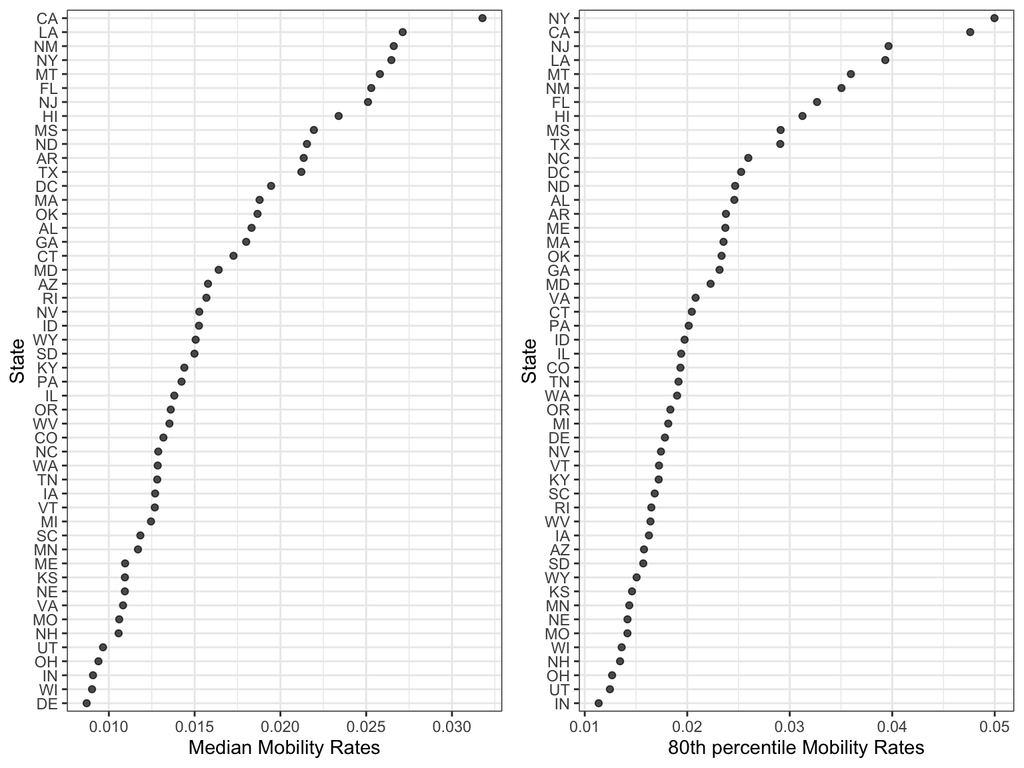

   ```r
   ## Plot 1 : median mobility by state
   ## Arrange by median mobility

   df_mobility <- df_mobility %>%
     mutate(state = factor(state),
            state = fct_reorder(state, median_mobility))

   p1 <- ggplot(df_mobility, aes(median_mobility, state)) +
     geom_point(alpha = 0.7) +
     labs(x = "Median Mobility Rates", y = "State") +
     theme_bw()

   ## Plot 2 : 80th percentile mobility by state
   ## Arrange by 80th percentile mobility

   df_mobility <- df_mobility %>%
     mutate(state = factor(state),
            state = fct_reorder(state, p80_mobility))

   p2 <- ggplot(df_mobility, aes(p80_mobility, state)) +
     geom_point(alpha = 0.7) +
     labs(x = "80th percentile Mobility Rates", y = "State") +
     theme_bw()

   ggpubr::ggarrange(p1, p2, ncol = 2, nrow = 1)
   ```

##### Question 3 (2 points)

As in the previous problem set, evaluate the following statements, and provide explanations if you think the statements do not make sense. Short responses are sufficient. You do not need to calculate anything.

1. In the definition of the variance, we first square the average deviation from the mean, and then calculate the average of those deviations. A colleague proposes a different way of calculating variability in the data. Instead of squaring the deviations, your colleague recommends just taking the “normal” difference between each observation and the mean of the data, and then taking the average of that (the mathematical representation of this would be $\frac{1}{N}\sum_{i}^N (x_i-\bar{x})$, where $\bar{x}$ is the sample mean). Is this a good approach of summarizing how much the sample varies?

   **Answers:**

   **This does not make sense, since this way of calculating the dispersion will include negative values, and might result in $\frac{1}{N}\sum_{i}^N (x_i-\bar{x})=0$.**
2. You analyze a variable, and find that the median is significantly larger than the mean. A colleague argues that this suggests outliers in the data. Specifically, your colleague suggests outliers in what is called the “right tail” of the distribution, i.e. values that are much larger than most other values that you observe.

   **Answer**:

   **This result suggests outliers, but not in the way described here – rather it suggests outliers that are much *smaller* than the other values of the empirical distribution. Therefore, this statement does not make sense.**
3. You are tasked with providing an estimate of the violent crime rate that the average person on the West Coast is exposed to. West Coast here refers to the states of California, Oregon and Washington. You use this state-level data from 2020 (see below). Your colleague suggests that an informative way of summarizing this data is to average over the three states, which results in an average exposure of 342.5 violent crimes per 100,000 inhabitants. Do you agree with this suggestion?

   | State | Violent crimes / 100,000 people |
   | --- | --- |
   | CA | 442.0 |
   | OR | 291.9 |
   | WA | 293.7 |

   **Answer:**

   **Note that the target quantity here is the violent crime rate that the *average person on the West Coast is exposed to*. California has significantly more inhabitants than Oregon and Washington combined. Using a weighted average, with the population as weights, makes more sense here. Therefore, the proposed approach does not make sense given the target quantity.**
4. Assume a variable, which takes on these values: (0,3,5,7,8,10,11). The median of the variable is 7. A colleague argues that the median will remain 7 even if we replace the first three values with any value smaller or equal than 7. The median will also remain 7 if we replace the last three values with any value greater or equal than 7.

   **Answer:**

   **This is correct.**

##### Question 4 (4 points)

An important concept in R are functions. A function in R is similar to a function takes one more arguments, and then returns the desired output. The syntax for functions is as follows:

```r
my_square <- function(x) {

  ## Calculate the square of x, save as new object
  x_sq <- x^2

  ## Return
  ## The last line usually just returns the desired output
  x_sq

}

## Expected output: 4
my_square(2)
```

```
## [1] 4
```

```r
## Expected output: 16
my_square(4)
```

```
## [1] 16
```

The function takes the input `x` and then returns its square. This works for any `x` that is a number.

Your task is to write a function `my_sd`. It takes a variable as its argument, and then returns the standard deviation of this variable. This involves calculating the mean of `x` (you can use the `mean` function for this), and then implementing the formula for the sample standard deviation that is given below:

$$\sqrt{\frac{1}{N - 1}\sum_{i=1}^N (x_i -
\overline{x})^2}$$

In this example, you will implement this function and then use the function you created to calculate the standard deviation of `sat_avg_2013` from the `chetty_data.csv` data set we used above. Please note the following:

- `sat_avg_2013` contains missing values. For $N$, we only want the number of non-missing observations. The simplest way to deal with this is to remove all missing values in `sat_avg_2013` before the main calculations – this can be done inside the function.
- Do not use the built-in `var` and `sd` functions in your function. You can use `sd` to check if your function returns the correct standard deviation.
- This can be achieved using a loop, but a loop is actually not necessary for this problem.

```r
df <- read.csv("/Users/yu-shiuanhuang/Desktop/method-sequence/data/chetty_data.csv")

x <- df$sat_avg_2013

my_sd <- function(x) {

  ## Remove missings from x
  x <- x[!is.na(x)]

  ## Mean of x, observations
  m_x <- mean(x)
  n <- length(x)

  ## Get sum of squared differences
  ss <- sum((x - mean(x))^2)

  ## Divide by n-1 (sample variance)
  sample_variance <- ss/(n-1)

  ## Square root to get SD
  standard_dev <- sqrt(sample_variance)

  ## return this
  standard_dev
}

## Try if this works
my_sd(df$sat_avg_2013)
```

```
## [1] 138.9658
```

```r
## Compare with sd function (with na.rm = T to remove missings
sd(df$sat_avg_2013, na.rm = T)
```

```
## [1] 138.9658
```

##### Additional question (required for students in the methods subfield)

**Note:** You may encounter R commands that you have not seen before. A good source for learning more about these commands is the book “R for Data Science” by Wickham et al, which you can access here https://r4ds.hadley.nz/

##### Question 5

1. Using a for loop, calculate the mean and standard deviation of the following variables in the Chetty data: `sat_avg_2013`, `par_median`, `par_top1pc`. The result should be a data frame with 3 columns: `variable`, `mean` and `sd`, and three rows, one for each variable.

   ```r
   ## Create empty data frame
   df_loop <- data.frame(
     variable = character(),
     mean = numeric(),
     sd = numeric()
   )

   ## Create vector of variables
   vars <- c("sat_avg_2013", "par_median", "par_top1pc")

   ## Loop over vars
   for (i in vars) {

     ## Calculate mean and sd
     mean_i <- mean(df[[i]], na.rm = T)
     sd_i <- sd(df[[i]], na.rm = T)

     ## Add to df_loop
     df_loop <- df_loop %>%
       add_row(variable = i,
               mean = round(mean_i, 4),
               sd = round(sd_i, 4))
   }

   knitr::kable(df_loop, "simple", align = "lll")
   ```

   | variable | mean | sd |
   | --- | --- | --- |
   | sat_avg_2013 | 1072.8991 | 138.9658 |
   | par_median | 93145.9582 | 29085.3233 |
   | par_top1pc | 0.0254 | 0.0362 |

2. In R, an alternative to for loops are the `apply` family of functions. Repeat subquestion 1 using the `apply` function of your choice (eg., `apply`, `sapply`, `lapply`). The output should be the same as for subquestion 1.

   Before we discuss the solution to this question, I’d like to share some notes about the `apply` family of functions in R.
   1. What are `apply` functions?

      `apply` functions are a family of functions in base R which allow you to repetitively perform an action on multiple chunks of data. An `apply` function is essentially a loop, but run faster than loops and often require less code. There are so many different `apply` functions because they are meant to operate on different types of data (e.g., `lapply`, `sapply`, `tapply`, and `mapply`.)
   2. The `apply` function

      First, let’s go over the basic `apply` function. The basic `apply` function looks like this: `apply(X, MARGIN, FUN)`.
      - X is an **array**, **matrix**, or **data.frame** (this is the data that you will be performing the function on).
      - Margin specifies whether you want to apply the function across rows (1) or columns (2).
      - FUN is the function you want to use.

      Example:

      `my.matrx` is a matrix with 1-10 in column 1, 11-20 in column 2, and 21-30 in column 3. `my.matrx` will be used to show some of the basic uses for the `apply` function.

      ```r
      my.matrx <- matrix(c(1:10, 11:20, 21:30), nrow = 10, ncol = 3)
      my.matrx
      ```

      ```
      ##       [,1] [,2] [,3]
      ##  [1,]    1   11   21
      ##  [2,]    2   12   22
      ##  [3,]    3   13   23
      ##  [4,]    4   14   24
      ##  [5,]    5   15   25
      ##  [6,]    6   16   26
      ##  [7,]    7   17   27
      ##  [8,]    8   18   28
      ##  [9,]    9   19   29
      ## [10,]   10   20   30
      ```

      Now, let’s use the `apply` function to find the row sums of `my.matrx`.

      ```r
      apply(my.matrx, 1, sum) ## bc we are using rows, margin = 1
      ```

      ```
      ##  [1] 33 36 39 42 45 48 51 54 57 60
      ```

      The `apply` function returned a vector containing the sums for each row.

      What if I wanted to be able to find how many datapoints (n) are in each column of `my.matrx`? I can use the length function to do this. Because we are using columns, MARGIN = 2.

      ```r
      apply(my.matrx, 2, length)
      ```

      ```
      ## [1] 10 10 10
      ```

      What if instead, I wanted to find n-1 for each column? There isn’t a function in R to do this automatically, so we can create my own function. If the function is simple, you can create it right inside the arguments for apply. In the arguments I created a function that returns `length` - 1.

      ```r
      apply(my.matrx, 2, function (x) length(x)-1)
      ```

      ```
      ## [1] 9 9 9
      ```

      The previous examples showed several ways to use the `apply` function on a **matrix**. But what if I wanted to loop through a vector instead? Will the `apply` function work?

      ```r
      vec <- c(1:10)
      vec
      ```

      ```
      ##  [1]  1  2  3  4  5  6  7  8  9 10
      ```

      ```r
      apply(vec, 1, sum)
      ```

      ```
      ## Error in apply(vec, 1, sum): dim(X) must have a positive length
      ```

      If you run the above line of code, it will return the error. As you can see, this didn’t work because `apply` was expecting the data to have at least two dimensions. If your data is a vector you need to use `lapply`, `sapply`, or `vapply` instead.
   3. The `lapply` function

      `lapply`, `sapply`, and `vapply` are all functions that will loop a function through data in a **list** or **vector** and then return a list of the same length as the input or a vector. Today, we will only introduce the `lapply` function. For more information about the `sapply` and `vapply` functions, please see [here](https://ademos.people.uic.edu/Chapter4.html#302_example_2:_sapply).

      The `lapply` function looks like this: `lapply(X, FUN, ...)`.

      Example:

      Consider, for instance, the following list with two elements named A and B.

      ```r
      a <- list(A = c(8, 9, 7, 5),
                B = data.frame(x = 1:5, y = c(5, 1, 0, 2, 3)))
      a
      ```

      ```
      ## $A
      ## [1] 8 9 7 5
      ##
      ## $B
      ##   x y
      ## 1 1 5
      ## 2 2 1
      ## 3 3 0
      ## 4 4 2
      ## 5 5 3
      ```

      If you apply the function sum to the previous list you will obtain the sum of each of its elements (the sum of the elements of the vector and the sum of the elements of the data frame).

      ```r
      lapply(a, sum)
      ```

      ```
      ## $A
      ## [1] 29
      ##
      ## $B
      ## [1] 26
      ```

      If you have a vector, the lapply function will apply a function to all elements to the vector. As an example, consider the vector b and calculate the square root of each element:

      ```r
      lapply(vec, sqrt)
      ```

      ```
      ## [[1]]
      ## [1] 1
      ##
      ## [[2]]
      ## [1] 1.414214
      ##
      ## [[3]]
      ## [1] 1.732051
      ##
      ## [[4]]
      ## [1] 2
      ##
      ## [[5]]
      ## [1] 2.236068
      ##
      ## [[6]]
      ## [1] 2.44949
      ##
      ## [[7]]
      ## [1] 2.645751
      ##
      ## [[8]]
      ## [1] 2.828427
      ##
      ## [[9]]
      ## [1] 3
      ##
      ## [[10]]
      ## [1] 3.162278
      ```

   Now let’s get back to the solution key to Question 5.2.

   ```r
   ## Create vector of variables
   vars <- c("sat_avg_2013", "par_median", "par_top1pc")

   ## Loop over vars
   list_loop <- lapply(vars, function(x) {

     ## Calculate mean and sd
     mean_i <- mean(df[[x]], na.rm = T)
     sd_i <- sd(df[[x]], na.rm = T)

     ## Add to list_loop
     c(x, round(mean_i, 4), round(sd_i, 4))
   })

   ## Note that this creates a list
   ## We can then convert this to a data frame
   df_loop <- list_loop %>%
     reduce(rbind) ## This "reduces" the list to a data frame

   ## Name each column
   colnames(df_loop) <- c("variable", "mean", "sd")

   knitr::kable(df_loop, "simple", align = "lll")
   ```

   |  | variable | mean | sd |
   | --- | --- | --- | --- |
   | out | sat_avg_2013 | 1072.8991 | 138.9658 |
   | elt | par_median | 93145.9582 | 29085.3233 |
   | elt | par_top1pc | 0.0254 | 0.0362 |

The standard deviation measures dispersion of the data. However, we can also create another measure of the dispersion of the sample mean, called the **standard error of the mean**. It is defined as follows: $s_{\bar{x}} = \frac{s_x}{\sqrt{N}}$, where $s_x$ is the standard deviation of a variable $x$, and $N$ is the number of observations.

**Some additional notes:** - The standard error of the mean measures how much discrepancy is likely in a sample’s mean compared with the population mean. - The standard error of the mean will always be smaller than the standard deviation.

3. Write a short function that calculates the SE of the mean, and takes a variable `x` as the argument. Then, calculate the mean and the SE of the mean for `par_median` separately for CA, NY, TX and FL. Finally, create a plot that has the name of each state on the x-axis. It should then show the mean of `par_median` as a point on the y-axis, and also show error bars that visualize the following interval: $[\bar{x}- 1.96s_{\bar{x}},\;\bar{x}+1.96 s_{\bar{x}}]$
- I recommend doing this in `ggplot` using the functions `geom_point` and `geom_errorbar`

  ```r
  ## Function to calculate SE of the mean
  my_se_mean <- function(x) {

    ## Remove missings from x
    x <- x[!is.na(x)]

    ## SE of the mean
    sd(x) / sqrt(length(x))
  }

  ## Calculate mean and SE of mean by state
  df_plot <- df %>%
    filter(state %in% c("CA", "FL", "TX", "NY")) %>%
    group_by(state) %>%
    summarise(x_bar = mean(par_median),
              x_bar_se = my_se_mean(par_median)) %>%
    ungroup()

  ## Divide by 1000s for better readability
  df_plot <- df_plot %>%
    mutate(across(all_of(c("x_bar", "x_bar_se")), ~./1000))
    ## across() allows you to apply a function to multiple columns at once. It's used to specify the columns you want to modify.
    ## '~' is a formula operator. '~./1000' is a simple formula where '.' is a pronoun referring to the column being transformed, and it's divided by 1000.


  knitr::kable(df_plot, "simple", align = "lll")
  ```

  | state | x_bar | x_bar_se |
  | --- | --- | --- |
  | CA | 100.35075 | 3.279516 |
  | FL | 82.32903 | 4.481775 |
  | NY | 91.84898 | 3.348163 |
  | TX | 86.83519 | 4.094647 |

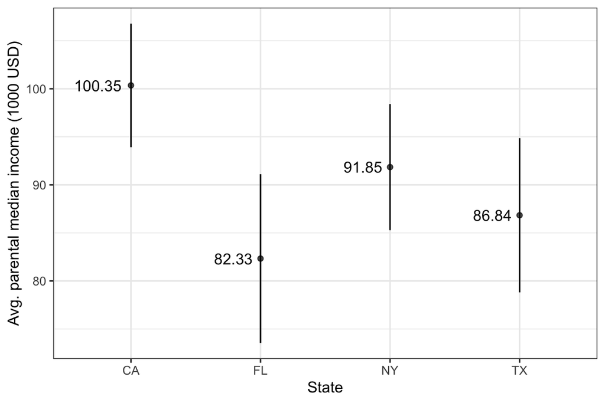

  ```r
  ## Plot this
  ggplot(df_plot, aes(state, x_bar)) +
    geom_errorbar(aes(ymin = x_bar - 1.96*x_bar_se,
                      ymax = x_bar + 1.96*x_bar_se),
                  width = 0) +
    geom_point(alpha = 0.7) +
    geom_text(aes(label = round(x_bar, 2)),
              position = position_dodge(0.9),
              hjust = 1.2) +
    theme_bw() +
    ylab("Avg. parental median income (1000 USD)") +
    xlab("State")
  ```

#### 2. Relationships in Data

When we want to describe the relationship between two sets of data, we can plot the data sets in a scatter plot and look at four characteristics:

- Direction: Are the data points sloping upwards or downwards?
- Form: Do the data points form a straight line or a curved line?
- Strength: Are the data points tightly clustered or spread out?
- Outliers: Are there data points far away from the main body of data?

Today, our focus will be on the first three characteristics. We will delve into covariance, the correlation coefficient, and linear regression. These are three fundamental statistics that allow us to describe the relationships between the variables of interest.

##### a. Visualizing Relationships – Scatter Plot

For today, we are using `Covid19.csv`. You can download this csv file from Canvas or from [here](https://drive.google.com/file/d/1CTjNdylGuBT5gMVgvNFla9YhuEhq_Yt7/view?usp=sharing).

```r
## load packages and import data
library(tidyverse)

cf <- read.csv("/Users/yu-shiuanhuang/Desktop/method-sequence/data/Covid19.csv")
```

Let’s visualize the relationship between the politics of a county (`dem16vs`) and the share of people who say they always wear a mask (`mask_always`) in a scatter plot.

- `dem16vs`: Democratic vote share in 2016 presidential election.
- `mask_always`: The estimated share of people in a county who would say they always wear a mask in public when they expect to be within six feet of another person.

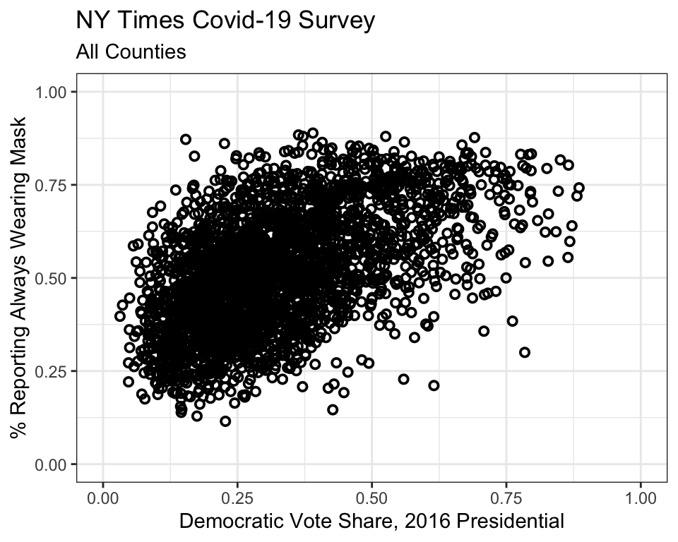

```r
ggplot(cf, aes(x = dem16vs, y = mask_always)) +
  geom_point(color = "black", fill = "white",
             stroke = 1, shape = 1) +
             ## Use the stroke aesthetic to modify the width of the border
             ## The shape of points can be adjusted by specifying the shape argument
  xlab("Democratic Vote Share, 2016 Presidential") +
  ylab("% Reporting Always Wearing Mask") +
  ylim(0,1) +
  xlim(0,1) +
  labs(title = "NY Times Covid-19 Survey",
       subtitle = "All Counties") +
  theme_bw()
```

The plot above is hard to see since all the dots are on top of each other. So instead of plotting all the datapoints, let’s draw a random sample of 500 of the rows of the dataset and plot them.

```r
set.seed(110) ## this allows us to draw the *same* random sample every time.

samp <- sample(1:nrow(cf), 500)
## This means randomly taking a sample of 500 from the elements of the total rows of cf
glimpse(samp)
```

```
##  int [1:500] 2008 2790 2483 336 2403 2921 1659 772 1427 2931 ...
```

`samp` is the rows we randomly sample from all the rows in `cf`. For example, the first element in `samp` is 2008, which means we’re going to draw the 2008th row out of the original dataset.

Now let’s replot the scatter plot again with only 500 datapoints we randomly drew from the whole dataset.

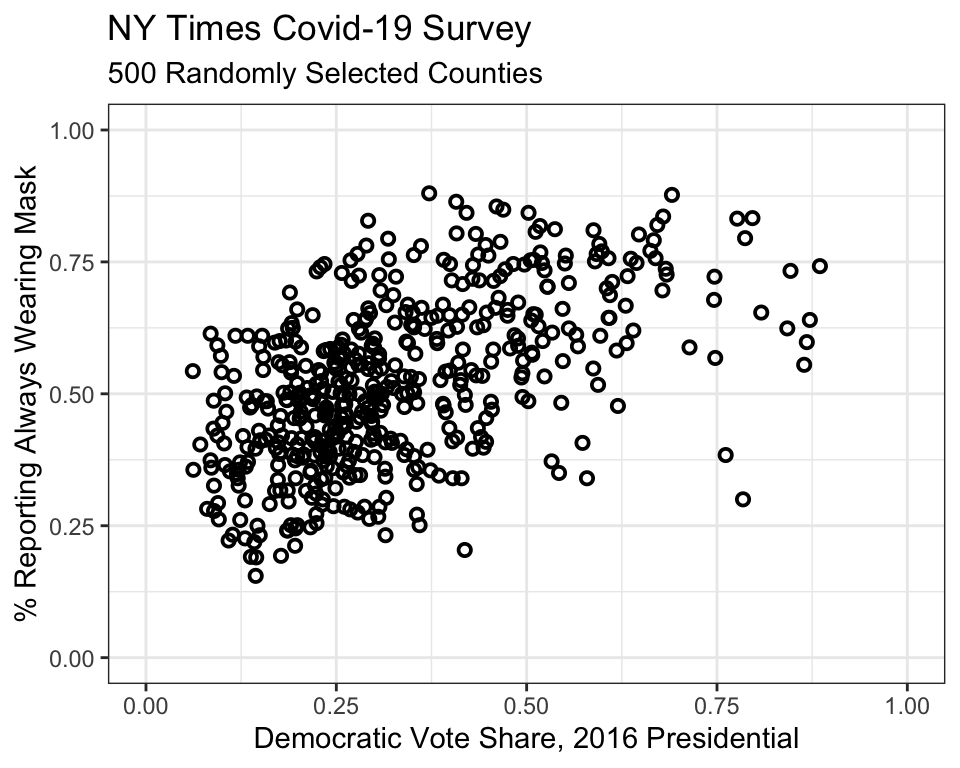

```r
ggplot(cf[samp,], aes(x = dem16vs, y = mask_always)) +
  ## Specify the random sample within the bracket of cf and remember to put it on the row position!
  geom_point(color = "black", fill = "white",
             stroke = 1, shape = 1) +
  xlab("Democratic Vote Share, 2016 Presidential") +
  ylab("% Reporting Always Wearing Mask") +
  ylim(0,1) +
  xlim(0,1) +
  labs(title = "NY Times Covid-19 Survey",
       subtitle = "500 Randomly Selected Counties") +
  theme_bw()
```

Be cautious about the axis scaling! Choosing how you scale the x and y axis doesn’t change the distribution or correlation, but it can mislead people!

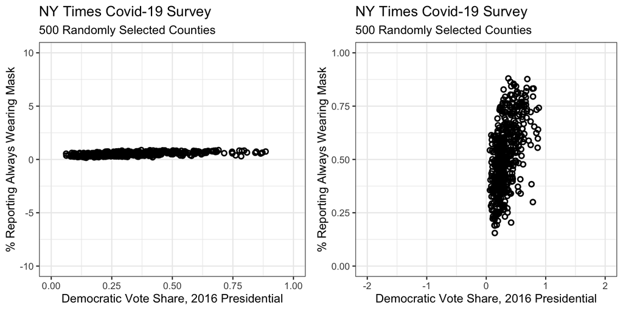

```r
p1 <- ggplot(cf[samp,], aes(x = dem16vs, y = mask_always)) +
  geom_point(color = "black", fill = "white",
             stroke = 1, shape = 1) +
  xlab("Democratic Vote Share, 2016 Presidential") +
  ylab("% Reporting Always Wearing Mask") +
  ylim(-10,10) + ## change the scale of y axis
  xlim(0,1) +
  labs(title = "NY Times Covid-19 Survey",
       subtitle = "500 Randomly Selected Counties") +
  theme_bw()

p2 <- ggplot(cf[samp,], aes(x = dem16vs, y = mask_always)) +
  geom_point(color = "black", fill = "white",
             stroke = 1, shape = 1) +
  xlab("Democratic Vote Share, 2016 Presidential") +
  ylab("% Reporting Always Wearing Mask") +
  xlim(-2,2) + ## change the scale of x-axis
  ylim(0,1) +
  labs(title = "NY Times Covid-19 Survey",
       subtitle = "500 Randomly Selected Counties") +
  theme_bw()

ggpubr::ggarrange(p1, p2, ncol = 2, nrow = 1)
```

##### b. Visualizing Relationships – Crosstab/Contingency Table

A crosstab or contingency table is also a way to observe the relationship between two variables.

Let’s look at the relationship between Covid-19 deaths and political breakdown of counties (whether the county voted for Trump or Clinton in 2016 presidential election). The goal is to replicate the same table as the one in the lecture slide (counties by vote choice and deaths/capita).

First, let’s create some new variables.

1. Looking at the variable on Covid-19 deaths, some of these counties are bigger, so will have more deaths. To account for this, we have to rescale the deaths data to be per capita.

   ```r
   cf <- cf %>%
     mutate(deaths.percap = c19deaths/population)

   cf %>%
     select(county_name, c19deaths, population, deaths.percap) %>%
     head()
   ```

   ```
   ##               county_name c19deaths population deaths.percap
   ## 1 Autauga County, Alabama      1563      55869   0.027976159
   ## 2 Baldwin County, Alabama      1858     223234   0.008323105
   ## 3 Barbour County, Alabama       331      24686   0.013408410
   ## 4    Bibb County, Alabama       257      22394   0.011476288
   ## 5  Blount County, Alabama       228      57826   0.003942863
   ## 6 Bullock County, Alabama      1025      10101   0.101475101
   ```

2. Generate a dummy variable indicating whether the county voted for Trump

   ```r
   cf <- cf %>%
     mutate(trump = ifelse(dem16vs < 0.5, "Voted Trump", "Voted Clinton"))

   cf %>%
     select(county_name, dem16vs, trump) %>%
     head() ## check the new var to see if we create it correctly
   ```

   ```
   ##               county_name    dem16vs         trump
   ## 1 Autauga County, Alabama 0.23769671   Voted Trump
   ## 2 Baldwin County, Alabama 0.19385601   Voted Trump
   ## 3 Barbour County, Alabama 0.46527844   Voted Trump
   ## 4    Bibb County, Alabama 0.21249575   Voted Trump
   ## 5  Blount County, Alabama 0.08425825   Voted Trump
   ## 6 Bullock County, Alabama 0.74946921 Voted Clinton
   ```

3. Generate a categorical variable indicating which deaths per capita quartile a county is in.

   ```r
   n25 <- ceiling(nrow(cf) * 0.25) ## The first quartile is in the 778th row
   n50 <- ceiling(nrow(cf) * 0.50) ## The second quartile is in the 1555th row
   n75 <- ceiling(nrow(cf) * 0.75) ## The third quartile is in the 2333rd row

   cf <- cf %>%
     arrange(deaths.percap) %>% ## Arrange the data based on the order of values in deaths.percap
     mutate(case_id = row_number()) %>%
     mutate(deaths.quartile = case_when(
       case_id >= 1 & case_id <= n25 ~ "1st Quartile Deaths/Capita",
       case_id > n25 & case_id <= n50 ~ "2nd Quartile Deaths/Capita",
       case_id > n50 & case_id <= n75 ~ "3rd Quartile Deaths/Capita",
       case_id > n75 ~ "4th Quartile Deaths/Capita",
     ))
   ```

4. Now, let’s create the crosstab: count the number of counties under different quartile deaths/capita and which candidate they voted for (Trump or Clinton).

   ```r
   crosstab <- cf %>%
     count(deaths.quartile, trump) %>%
     spread(trump, n) %>% ## After the count operation, this spreads the trump variable into separate columns, one for each unique value in the trump variable. It places the counts (n) for each trump value into their respective columns.
     mutate(Total = `Voted Clinton` + `Voted Trump`) ## Generate a column for the row total

   Total <- c("Total", unname(colSums(crosstab[, 2:4]))) ## Generate a row for the column total

   crosstab <- crosstab %>% rbind(Total)

   knitr::kable(crosstab, "simple", align = "llll")
   ```

   | deaths.quartile | Voted Clinton | Voted Trump | Total |
   | --- | --- | --- | --- |
   | 1st Quartile Deaths/Capita | 42 | 736 | 778 |
   | 2nd Quartile Deaths/Capita | 60 | 717 | 777 |
   | 3rd Quartile Deaths/Capita | 88 | 690 | 778 |
   | 4th Quartile Deaths/Capita | 212 | 565 | 777 |
   | Total | 402 | 2708 | 3110 |

   A crosstab does not make it easier to see the relationship. Usually, when the two variables you are interested in are cardinal ones (both `dem16vs` and `deaths.percap` are continuous variables), plotting a scatter plot is more straightforward to see the relationship. In general, crosstab/contingency table is more useful when the two variables you are interested in are both **categorical variables**.

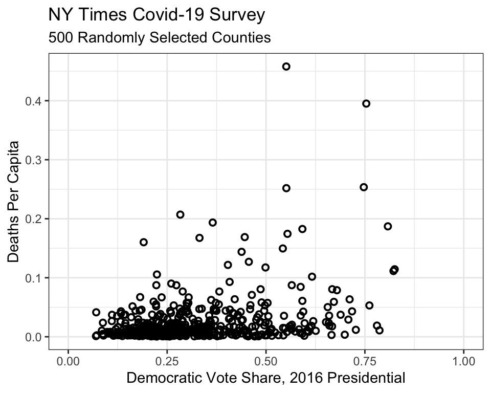

   ```r
   ggplot(cf[samp,], aes(x = dem16vs, y = deaths.percap)) +
     geom_point(color = "black", fill = "white",
                stroke = 1, shape = 1) +
     xlab("Democratic Vote Share, 2016 Presidential") +
     ylab("Deaths Per Capita") +
     xlim(0,1) +
     labs(title = "NY Times Covid-19 Survey",
          subtitle = "500 Randomly Selected Counties") +
     theme_bw()
   ```

##### c. Covariance, Correlation Coefficient, Linear Regression

In addition to visualizing data using scatter plots or contingency tables to grasp relationships, how can we employ statistical measures to describe these relationships more formally?

1. Covariance

   Covariance is a useful measure for describing the **direction** of the linear association between two quantitative variables.

   $$Cov(x, y) =
   \frac{1}{N-1}\sum_{i=1}^{N}(x_i-\bar{x})(y_i-\bar{y})$$
   As we can see from the equation, the covariance sums the term $(x_i-\bar{x})(y_i-\bar{y})$ for each data point, where $\bar{x}$ is the average $x$ value, and $\bar{y}$ is the average $y$ value. The term becomes more positive if both $x$ and $y$ are larger than the average values in the data set, and becomes more negative if smaller. As the covariance accounts for every data point in the set, a positive covariance must mean that most, if not all, data points are in sync with respect to $x$ and $y$ (small $y$ when $x$ is small or large $y$ when $x$ is large). Conversely, a negative covariance must mean that most, if not all, data points are out of sync with respect to $x$ and $y$ (small $y$ when $x$ is large or large $y$ when $x$ is small).

   Let’s start by using a fake dataset to practice how to compute covariance.

   ```r
   tf <- data.frame(x = c(3, 2, 1, 7, -1),
                    y = c(8, 10, 13, 2, 8))

   knitr::kable(tf, "simple", align = "cc")
   ```

   | x | y |
   | --- | --- |
   | 3 | 8 |
   | 2 | 10 |
   | 1 | 13 |
   | 7 | 2 |
   | -1 | 8 |

   ```r
   ## Covariance
   tf$x.dev2 <- tf$x - mean(tf$x)
   tf$y.dev2 <- tf$y - mean(tf$y)

   cov.fake <- (1/(nrow(tf)-1))*sum(tf$x.dev2*tf$y.dev2)
   cov.fake
   ```

   ```
   ## [1] -8.85
   ```

   You can use the canned function `cov()` to double check your answer.

   ```r
   ## Covariance
   cov(tf$x, tf$y)
   ```

   ```
   ## [1] -8.85
   ```

   Covariance is a useful measure at describing the direction of the linear association between two quantitative variables, but it has two weaknesses: a larger covariance does not always mean a stronger relationship, and we cannot compare the covariances across different sets of relationships. For example, if we find that the covariance between variables $x$ and $y$ is larger than the covariance between $x$ and $z$, we can only conclude that both $y$ and $z$ are positively associated with $x$. However, we cannot determine whether the relationship between $x$ and $y$ is stronger than the relationship between $x$ and $z based solely on their covariances.
2. Correlation Coefficient

   To account for the weakness, we normalize the covariance by the standard deviation of the $x$ values and $y$ values, to get the correlation coefficient. The correlation coefficient is a value between -1 and 1, and measures both the direction and the strength of the linear association. One important distinction to note is that correlation does not measure the slope of the relationship — a large correlation only speaks to the strength of the relationship. Some key points on correlation are:
   - Correlation measures the direction and strength of the linear association between two quantitative variables.
   - Positive and negative indicates direction, large and small indicates the strength.
   - Correlation has symmetry: correlation of x and y is the same as correlation of y and x.
   - Correlation is unitless and normalized.

   $$r_{xy}=\frac{Cov(x,
   y)}{s_xs_y}$$

   Please compute the correlation coefficient between $x$ and $y$ using the formula above with the fake dataset

   ```r
   ## Correlation
   cor.fake <- cov.fake/(sd(tf$x)*sd(tf$y))
   cor.fake
   ```

   ```
   ## [1] -0.7412154
   ```

   You can also used the canned function `cor()` to double check your answers.

   ```r
   ## Correlation
   cor(tf$x, tf$y)
   ```

   ```
   ## [1] -0.7412154
   ```

3. Linear Regression

   Correlation and covariance are quantitative measures of the strength and direction of the relationship between two variables, but they do not account for the slope of the relationship. In other words, we do not know **how a change in one variable could impact the other variable**. Regression is the technique that fills this void — it allows us to make the best guess at how one variable affects the other variables. The simplest linear regression, which is usually measured by ordinary least square (OLS) method, allows us to fit a “line of best fit” to the scatter plot, and use that line (or model) to describe the relationship between the two variables. The OLS approach aims to fit a line that minimizes squared residuals. The equation for that line is:

   $$\hat{y} = a + bx$$
   The equations of $a$ and $b$ are:

   $$b =
   \frac{r_{xy}s_{y}}{s_{x}}=\frac{Cov(x, y)}{s^2_{x}}$$

   $$a = \bar{y}-b\bar{x}$$
   **Note**: A more detailed introduction regarding linear regression will be discussed in POL 212 and 213.

   What are the intercept ($a$) and slope ($b$) between $x$ and $y$ in the fake dataset? Please compute in a manual way!

   ```r
   ## Slope
   b <- cov(tf$x, tf$y)/var(tf$x)

   ## Intercept
   a <- mean(tf$y) - b * mean(tf$x)
   ```

   You can also use the canned function `lm` to check your answer.

   ```r
   reg <- lm(y ~ x, data = tf)
   stargazer::stargazer(reg, type = "text", digits = 4)
   ```

   ```
   ##
   ## ===============================================
   ##                         Dependent variable:
   ##                     ---------------------------
   ##                                  y
   ## -----------------------------------------------
   ## x                             -1.0057
   ##                              (0.5258)
   ##
   ## Constant                     10.6136**
   ##                              (1.8813)
   ##
   ## -----------------------------------------------
   ## Observations                     5
   ## R2                            0.5494
   ## Adjusted R2                   0.3992
   ## Residual Std. Error       3.1198 (df = 3)
   ## F Statistic             3.6578 (df = 1; 3)
   ## ===============================================
   ## Note:               *p<0.1; **p<0.05; ***p<0.01
   ```

##### d. Practice

Now that you know how to use covariance, correlation coefficients, and linear regression to describe relationships in data, let’s apply what you’ve learned to the `Covid19.csv` dataset to compute the covariance, correlation coefficient, and regression line between `dem16vs` and `mask_always`.

1. What is the covariance and correlation coefficient between `dem16vs` and `mask_always`? Please compute them in a manual way.

   ```r
   ## Covariance
   dem16vs.dev <- cf$dem16vs[samp]  - mean(cf$dem16vs[samp])
   mask_always.dev <- cf$mask_always[samp] - mean(cf$mask_always[samp])

   cov.covid19 <- (1/(500 - 1))*sum(dem16vs.dev*mask_always.dev)
   cov.covid19
   ```

   ```
   ## [1] 0.01364536
   ```

   ```r
   cov(cf$dem16vs[samp], cf$mask_always[samp])
   ```

   ```
   ## [1] 0.01364536
   ```

   ```r
   ## Correlation
   cor.covid19 <- cov.covid19/(sd(cf$dem16vs[samp])*sd(cf$mask_always[samp] ))
   cov.covid19
   ```

   ```
   ## [1] 0.01364536
   ```

   ```r
   cor(cf$dem16vs[samp], cf$mask_always[samp])
   ```

   ```
   ## [1] 0.5636262
   ```

2. What are the intercepts and slopes for the regression line between `dem16vs` and `mask_always`? Note that in this practice, we are calculating the regression line based on the 500 randomly selected counties!

   ```r
   ## Please find a and b!
   b <- cov(cf$dem16vs[samp], cf$mask_always[samp])/var(cf$dem16vs[samp])
   a <- mean(cf$mask_always[samp]) - b * mean(cf$dem16vs[samp])
   print(paste0("y = ", round(a, 2), " + ", round(b, 2), "x"))
   ```

   ```
   ## [1] "y = 0.33 + 0.56x"
   ```

3. Now you have the regression line, please add the line on the scatter plot using `geom_abline()`!

[figure not shown]

### Discussion IV

In today’s discussion, we’ll start by reviewing the solutions to Problem Set 3. Afterward, we’ll dive into the first part of “Learning from Data.” During this session, we’ll revisit the fundamental concept of the data generating process and underscore the significance of understanding probability theory as a foundational step in data analysis. Furthermore, we’ll practice computing joint, marginal, and conditional distributions, and develop skills for summarizing central tendency and dispersion within these distributions.

#### 1. Solution Keys to Problem Set 3

##### Question 1 (3 points)

Each subquestion in this question assumes new “data”, i.e. the quantities listed in (1) are irrelevant for (2), and so on.

##### Question 1.1

Below, you will find a table with values for variables $X$ and $Y$. The mean of $X$ is 1, and the mean of $Y$ is 3.

| $x_i$ | $y_i$ |
| --- | --- |
| 0 | 4 |
| 0 | 3 |
| 3 | 2 |

Without using R, calculate the sample covariance between $X$ and $Y$. Note that the sample covariance uses $n-1$ in the denominator. Briefly state what the covariance tells us about the relationship between $X$ and $Y$.

**Answer:**

**$Cov(X,Y) = \frac{1}{2} \sum_{i=1}^3 (x_i - \bar{x})(y_i - \bar{y}) = \frac{1}{2} \left[ (0-1)(4-3) + (0-1)(3-3) + (3-1)(2-3) \right] = -1.5$**

**The covariance suggests a negative relationship between $X$ and $Y$.**

##### Question 1.2

Next, assume you have two other variables $X$ and $Y$. A colleague tells you that the covariance between $X$ and $Y$ is 2, the variance of $X$ is 9, and the variance of $Y$ is 16. Your colleage argues that the covariance of 2 implies a strong relationship between $X$ and $Y$. Please state if you do or do not agree with your colleague, and explain why. If you do not agree, calculate an alternative measure of the relationship between $X$ and $Y$, which may be more informative.

**Answer:**

**Incorrect. The covariance is sensitive to the scale of the variables. Instead, we can calculate the scale-invariant correlation coefficient, which is defined as $r_{XY} = \frac{Cov(X,Y)}{\sqrt{Var(X)} \sqrt{Var(Y)}}$. In this case, $r_{XY} = \frac{2}{3\times4} = \frac{2}{12} = \frac{1}{6}$.**

##### Question 1.3

Assume you run a least squares regression the regresses one variable $Y$ on another variable $X$ and this results in predicted values $\hat{y}_i$, while the observed values are denoted by $y_i$. Which of the following statements is true / not true? Please include a brief explanation for each statement.

1. Running a least squares regression minimizes the sum of the differences between the observed and predicted values, i.e. it minimizes $\sum_{i=1}^n (y_i - \hat{y}_i)$.

   **Answer:**

   **False. The least squares regression minimizes the sum of squared residuals, i.e. $\sum_{i=1}^n (y_i - \hat{y}_i)^2$.**
2. The intercept $\alpha$ tells us about the value of the dependent variable $Y$ when the independent variable $X$ is at its mean (i.e. when $x_i = \bar{x}$).

   **Answer:**

   **False. The intercept $\alpha$ is the value of $Y$ when $x_i=0$.**

##### Question 2 (3 points)

This question is similar to the previous one, but uses R.

You are given two variables $X$ and $Y$ in the code below. In addition, there is some code that calculates the sample mean of each variable. Please also calculate the following quantities in R:

- The sample standard deviation of $X$ and $Y$
- The covariance between $X$ and $Y$
- The correlation between $X$ and $Y$

**Note:** Do not use the built in functions to do this, i.e. you should not use `var`, `sd`, `cov`, `cor` or similar functions. Rather, the goal is to calculate these quantities “by hand”, i.e. using the formulas from the lecture. You can of course use functions such as `sum` and `sqrt`. After you are done, you can use `cor` to check if your code produces the same answer as the built-in function.

Also, please remember that the sample standard deviation and sample covariance use $n-1$ in the denominator, but the sample mean uses $n$.

```r
x <- c(2, 5, 3, 6, 7, 8, 3, 6, 7, 9)
y <- c(9, 6, 8, 4, 7, 5, 4, 3, 3, 2)

# Get number of observations
n <- length(x)

# Calculate the mean of each variable
# "Sum" just takes all elements of X and then adds them up
mean_x <- sum(x) / n
mean_y <- sum(y) / n

# Your code:

# ...
```

**Answer:**

```r
# Variance of X,Y
var_x <- sum((x - mean_x)^2) / (n - 1)
var_y <- sum((y - mean_y)^2) / (n - 1)

# SD of X,Y
sd_x <- sqrt(var_x)
sd_y <- sqrt(var_y)

# Covariance between X,Y
cov_xy <- sum((x - mean_x) * (y - mean_y)) / (n - 1)

# Correlation between X,Y
cor_xy <- cov_xy / (sd_x * sd_y)
cor_xy
```

```
## [1] -0.6495461
```

```r
# We can check if the results are correct by using the built-in functions
cov(x, y)
```

```
## [1] -3.511111
```

```r
cor(x, y)
```

```
## [1] -0.6495461
```

##### Question 3 (4 points)

We will use the Chetty data from the last problem set again. A policymaker is interested in the relationship between mobility rates and price of attendance for public universities in California, Oregon and Washington.

First, you will need to transform the data, which means (i) subsetting the data set to California, Oregon and Washington and (ii) subsetting the data set to public universities within these states. Next, transform the variable `sticker_price_2013` into a variable that measures the price of attendance in 2013 in thousands of dollars. Then, transform the variable `mr_kq5_pq1` into a variable that measures the mobility rate in percentage points, rather than on a 0–1 scale.

##### Question 3.1

Create a scatter plot of the relationship between mobility rates (`mr_kq5_pq1`) and price of attendance (`sticker_price_2013`). For a definition of mobility rates, see here: https://opportunityinsights.org/wp-content/uploads/2018/03/coll\_mrc\_summary.pdf

```r
library(tidyverse, quietly = TRUE)

# Read the data
df <- read.csv("/Users/yu-shiuanhuang/Desktop/method-sequence/data/chetty_data.csv")
```

**Answer:**

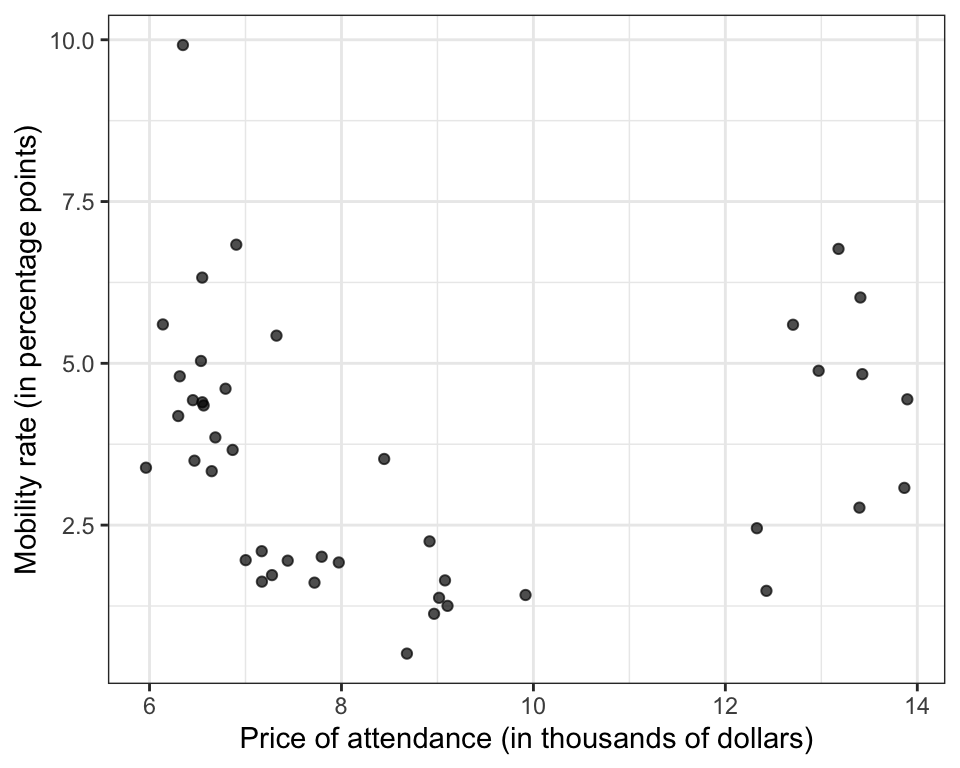

```r
# Subset to the three states
df_west <- df %>%
    filter(state %in% c("CA", "WA", "OR")) %>%
    filter(public == "Public") %>%
    mutate(sticker_price_2013 = sticker_price_2013/1000,
           mr_kq5_pq1 = mr_kq5_pq1*100)

# Scatter plot
ggplot(df_west, aes(x = sticker_price_2013, y = mr_kq5_pq1)) +
    geom_point(alpha = 0.7) +
    labs(x = "Price of attendance (in thousands of dollars)",
         y = "Mobility rate (in percentage points)") +
    theme_bw()
```

##### Question 3.2

Run a linear regression using the `lm` command, where the outcome is mobility rates and the predictor is price of attendance. You should use the same data set as before, i.e. public universities in WA, CA and OR. Interpret the intercept and slope of the regression. You do not have to interpret standard errors or p-values.

**Answer:**

```r
mod <- lm(mr_kq5_pq1 ~ sticker_price_2013, data = df_west)

stargazer::stargazer(mod, type = "text", digits = 4)
```

```
##
## ===============================================
##                         Dependent variable:
##                     ---------------------------
##                             mr_kq5_pq1
## -----------------------------------------------
## sticker_price_2013            -0.0194
##                              (0.1158)
##
## Constant                     3.7499***
##                              (1.0538)
##
## -----------------------------------------------
## Observations                    43
## R2                            0.0007
## Adjusted R2                   -0.0237
## Residual Std. Error      1.9959 (df = 41)
## F Statistic             0.0280 (df = 1; 41)
## ===============================================
## Note:               *p<0.1; **p<0.05; ***p<0.01
```

**Answer:**

**The intercept is the mobility rate for a public college with a price of attendance of 0 (i.e. this number is not very useful). The slope is the change in mobility rate, in percentage points, associated with a 1,000 dollar increase in price of attendance.**

##### Question 3.3

Plot the same scatter plot as in subquestion 1, but now add the linear regression line that you just calculated. In `ggplot`, you can do this either manually using the `geom_abline` command, or you can use the `geom_smooth(method = 'lm')` command. Given what you just plotted, do you think the linear regression is a good fit? Please explain why or why not.

**Answer:**

**Plot suggests nonlinearity – linear regression not a good fit!**

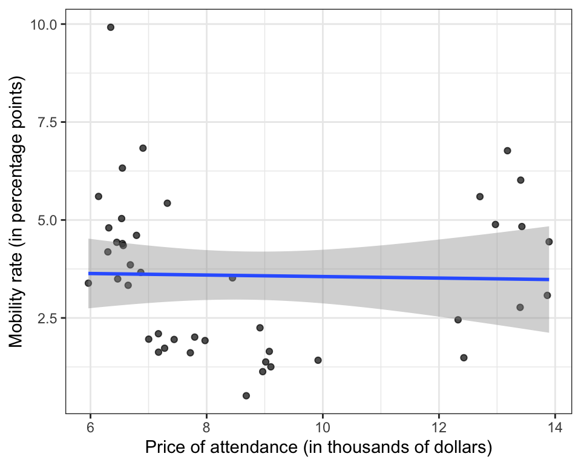

```r
ggplot(df_west, aes(x = sticker_price_2013, y = mr_kq5_pq1)) +
    geom_point(alpha = 0.7) +
    geom_smooth(method = "lm") +
    labs(x = "Price of attendance (in thousands of dollars)",
         y = "Mobility rate (in percentage points)") +
    theme_bw()
```

##### Question 3.4

We can also assess this relationship *non-parametrically*. In the previous question, we used a regression model to model the values of $Y$ given $X$. We can also just calculate the conditional mean of $Y$ given some values of $X$. To implement this, proceed as follows: calculate the average mobility rate separately for 4 groups of the data, defined by their cost of attendance:

1. Between 5,000 and 8,000 dollars
2. Between 8,000 and 10,000 dollars
3. Between 10,000 and 12,000 dollars
4. Above 12,000 dollars

The quantities you just calculated are called *conditional means*. Then, create a plot that has these groups on the x-axis, and the average of each group on the y-axis (e.g. a bar chart).

You will likely find that it is not always possible to calculate the conditional mean of $Y$, particularly when there are no observed outcomes $Y$ for certain values of $X$. Comparing the regression method to the conditional mean method, what is one advantage of the regression method in cases where there is no available data on $Y$ for certain values of $X$?

**Answer:**

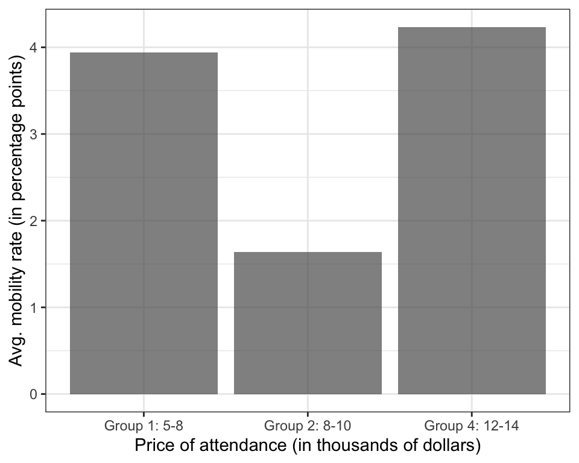

```r
# Create a new variable that indicates the group
df_west <- df_west %>%
    mutate(group = case_when(
      sticker_price_2013 >= 5 & sticker_price_2013 < 8 ~ "Group 1: 5-8",
      sticker_price_2013 >= 8 & sticker_price_2013 < 10 ~ "Group 2: 8-10",
      sticker_price_2013 >= 10 & sticker_price_2013 < 12 ~ "Group 3: 10-12",
      sticker_price_2013 >= 12 ~ "Group 4: 12-14"))

# Calculate conditional means
df_plot <- df_west %>%
    group_by(group) %>%
    summarize(mean_mr = mean(mr_kq5_pq1, na.rm = TRUE))

# Plot as bar chart
df_plot %>%
    ggplot(aes(x = group, y = mean_mr)) +
    geom_bar(stat = "identity", alpha = 0.7) +
    labs(x = "Price of attendance (in thousands of dollars)",
         y = "Avg. mobility rate (in percentage points)") +
    theme_bw()
```

**Note that the third group has no data for $Y$, which leads to a missing value. The advantage of the regression method is that we can still predict values of $Y$ for this group, even though we have no data for this group – the regression equation will give us predictions of $Y$ for any value of $X$.**

##### Question 4 (2 points)

##### Question 4.1

Please interpret the following regression coefficients:

- Gentzkow et al (2011) study the relationship between *number of local newspapers* in a county and *voter turnout* in presidential elections, for all elections between 1868–1928. Turnout ($Y$) ranges from 0–1, with 1 indicating 100% turnout. The newspaper variable ($X$) is simply the number of newspapers. Based on results in table 2 of the paper, the estimated regression coefficient $\beta$ that stems from the regression of changes in turnout on the number of newspapers is 0.0034. Please interpret this coefficient.

  **Answer:**

  **One additional local newspapers is associated with a 0.34 percentage point increase in turnout.**
- Enos (2014) conducts a field experiment to assess the relationship between exposure to Spanish-speaking confederates and attitudes toward immigration policy. He randomly assigns certain train platforms to receive a treatment for 2 weeks, where pairs of Spanish-speaking confederates visit the platforms every day during the morning commute to simulate demographic change. He then surveys commuters before and after the treatment about their attitudes toward immigration policy. One of the dependent variables is support for decreasing the number of immigrants from Mexico, measured on a 0-1 scale where 1 indicates support for decreasing immigration. In the full sample, the estimated regression coefficient $\beta$ stemming from the regression of support for decreasing immigration on exposure to the Spanish-speaking confederates (the treatment) is 0.09. Note that this is an experiment, so there is a treatment group that sees the Spanish-speaking confederates ($x_i = 1$) and a control group that does not get exposed to the confederates ($x_i=0$). Please interpret the coefficient $\beta$.

  **Answer:**

  **Exposure to Spanish-speaking confederates (compared to the control group) is associated with a 0.09-point increase in support for decreasing the number of immigrants from Mexico, on a scale from 0–1.**

##### Question 4.2

Let’s return to the Chetty data. We will look at the dataset for the whole country and for public as well as private colleges. The dataset has a variable called `mobility_above_average`, which is defined as follows:

$$mobility\_above\_average = \begin{cases}
1 & mobility\_rate_i > \overline{mobility\_rate} \\ 0 &
mobility\_rate_i \leq \overline{mobility\_rate} \end{cases}$$

This variable indicates whether the mobility rate for a given college is above or below the average mobility rate across all colleges. It can only take two values – 1 (greater than the average) or 0 (equal to or below the average).

We now run the following regression:

```r
mod <- lm(mobility_above_average ~ public, data = df)
coef(mod)
```

```
##  (Intercept) publicPublic
##    0.3184358    0.1361097
```

Interpret the coefficients.

**Answer:**

**The intercept is the share of private colleges with above-average mobility rates. The coefficient $\beta$ is the difference in the share of public colleges with above-average mobility rates, compared to private colleges. It is positive, so public colleges are more likely to have above-average mobility rates.**

##### Question 5 (required for students in the methods subfield, 3 points)

##### Question 5.1

In lecture, we said the mean $\bar{x} = \frac{1}{n} \sum_{i=1}^n x_i$ is the best “guess” of $x_i$ in terms of minimizing the mean squared error. In statistics, it is common to define some measure of how “good” a guess or an estimate is, and then to show that there is some specific estimate that is “best” in terms of this measure. Recall that the mean squared error is defined as
$$MSE =
\frac{1}{n} \sum_{i=1}^n (x_i - \hat{x})^2$$
where $\hat{x}$ is our guess of $x_i$.

- Show that the mean $\bar{x}$ is the best guess in terms of minimizing the mean squared error given above.
- To show this, you will use calculus. Recall that we can use derivatives to find mimima / maxima of a function. Commonly, we proceed as follows: (1) we take the derivate of a function with respect to the variable we want to optimize over, (2) we set the derivative equal to zero, and (3) we solve for the variable we want to optimize over. In this case, we want to optimize over $\hat{x}$, so we will take the derivative of the mean squared error with respect to $\hat{x}$, set it equal to zero, and solve for $\hat{x}$. The goal is then to show that $\hat{x} = \bar{x}$ is the solution to this problem.
- **Note 1:** Usually, we would also have to assess whether we found a minimum or maximum by looking at the second derivative. However, you can just assume that you found a minimum here – looking at the second derivative is not necessary.
- **Note 2:** You can use the fact that $\sum_{i=1}^n a = n a$, since $a$ is just a constant.

**Answer:**

**The MSE is defined as follows:**

$$MSE = \frac{1}{n} \sum_{i=1}^n
(x_i - \hat{x})^2$$

**Note that we can also write this as follows:**

$$MSE = \frac{1}{n} \sum_{i=1}^n
(x_i^2 - 2x_i \hat{x}+ \hat{x}^2)$$

**Next, we take the derivate of this wrt $\hat{x}$:**

$$\frac{\partial MSE}{\partial
\hat{x}} = \frac{1}{n} \sum_{i=1}^n (-2x_i +
2\hat{x})$$

**Since we take the derivative wrt $\hat{x}$, we can treat all other terms as constants, which is why the $x^2_i$ term disappears. Next, we set this equal to zero and solve for $\hat{x}$:**

$$\frac{1}{n} \sum_{i=1}^n (-2x_i
+ 2\hat{x}) = 0$$

$$\frac{1}{n} \sum_{i=1}^n -2x_i +
\frac{1}{n} \sum_{i=1}^n 2\hat{x} = 0$$

**The second sum is just the sum of constants, i.e. $\sum_{i=1}^n 2\hat{x} = 2n\hat{x}$.**

$$\frac{1}{n} \sum_{i=1}^n -2x_i +
\frac{1}{n}2n\hat{x} =
\frac{-2}{n} \sum_{i=1}^n x_i + 2\hat{x} = 0$$

**Note that the first term is negative, so we can just move it to the other side of the equation and divide by 2.**

$$2\hat{x} = \frac{2}{n}
\sum_{i=1}^n x_i$$

$$\hat{x} = \frac{1}{n}
\sum_{i=1}^n x_i$$

**Note that the right-hand side is just the definition of the mean, i.e. we have shown that $\hat{x} = \bar{x}$. As stated above, we would now have to look at the second derivative to see if we found a minimum or maximum. However, you can just assume that we found a minimum here.**

##### Question 5.2

In linear regressions, goodness of fit is usually measured using the $R^2$ statistic. This statistic is defined as follows:

$$R^2 = 1 - \frac{SSR}{SST}$$

where the sum of squared residuals $SSR = \sum_{i=1}^n (y_i - \hat{y}_i)^2$ and the total sum of squares $SST = \sum_{i=1}^n (y_i - \bar{y})^2$. Here, $\hat{y}_i$ are the predicted values of $y_i$ from the regression, and $y_i$ are the observed values of $Y$.

In R, write a function that calculates $R^2$ for a given regression, based on the definition given above. The function should have two arguments: (1) the observed values $y_i$ and (2) an `lm` object that contains the regression results of a regression of $Y$ on $X$. The function should return the $R^2$ statistic.

```r
x <- c(2, 5, 3, 6, 7, 8, 3, 6, 7, 9)
y <- c(9, 6, 8, 4, 7, 5, 4, 3, 3, 2)

mod <- lm(y ~ x)

get_rsq  <- function(y, lm_object) {

  # Your code here

}
```

**Answer:**

```r
get_rsq  <- function(y, lm_object) {

  # Get predicted values
  y_hat <- predict(lm_object)

  # Get SSR
  SSR <- sum((y - y_hat)^2)

  # Get SST
  SST <- sum((y - mean(y))^2)

  # Get R^2
  R_sq <- 1 - SSR / SST

  # Return R^2
  return(R_sq)

}

get_rsq(y, mod)
```

```
## [1] 0.4219101
```

##### Question 5.3

If $R^2$ is closer to 1, this is usually considered a better fit.

1. First, provide an intuitive explanation why $R^2$ is a measure of goodness of fit. For this, it is helpful to consider cases where SSR is small relative to SST, and cases where SSR is large relative to SST.

   **Answer:**

   **SST measures the overall deviation of $Y$ from its sample mean. SSR measures the deviation of the predicted values $\hat{y}_i$ from the actual values. If SSR is small relative to SST, then the difference between the predicted and observed values is small, so our model does well. This will then lead to larger values of $R^2$. If SSR is large relative to SST, then the difference between the predicted and observed values is large, so our model does not do well. This will then lead to smaller values of $R^2$.**
2. Second, please state whether $R^2$ tells us something about the direction of the relationship between $X$ and $Y$.

   **Answer:**

   **Note that the definition of $R^2$ does not contain $X$. Therefore, $R^2$ does not tell us anything about the direction of the relationship between $X$ and $Y$. It merely tells us whether $X$ is a good predictor of $Y$.**
3. Third, assume we are interested in explaining whether citizens vote for Democrats or Republicans. Many different variables are correlated with voting behavior, such as age, income, gender, race, etc. For many of these variables, we can find a “statistically significant” relationship with voting behavior. However, the $R^2$ of regressing voting behavior on these variables is usually quite low (e.g. $<0.2$), which indicates that a given $X$ only explains a small part of the variation in $Y$. However, researchers in social science generally do not consider this a problem. Please explain why not.

   **Answer:**

   **Taken from Gailmard, page 51: “the object of our analysis […] is typically not to give a complete account of the behavior of $Y$ in a specific sample but rather to identify a set of factors that systematically affect $Y$ and to give reasons behind these effects.”**

##### Question 6 (extra credit, 1 point)

A famous question on StackExchange is as follows (with some edits for clarity):

> “Suppose we have data set $(y_i, x_i)$ with $n$ [observations]. We want to perform a linear regression, but first we sort the $x_i$ values and the $y_i$ values independently of each other, forming data set $(y_j, x_j)$ Is there any meaningful interpretation of the regression on the new data set? Does this have a name?

> I imagine this is a silly question so I apologize, I’m not formally trained in statistics. […] [M]y manager says he gets “better regressions most of the time” when he does this (here “better” means more predictive). I have a feeling he is deceiving himself.”

What would you respond to this? What could one likely reason be why the manager gets more predictive regressions with this method?

**Answer:**

**This makes no sense at all, and completely destroys the actual relationship between $X$ and $Y$. By sorting both variables independently, the manager creates a meaningless data set where both $X$ and $Y$ become artificially correlated because they are both increasing in value as we go down the list of observations.**

#### 2. Learning from Data I

**Note**: Most of the materials for today’s discussion can be referred to [STAT 414: Introduction to Probability Theory.](https://online.stat.psu.edu/stat414/).

1. Data Generating Process (DGP)

   The contemporary world is full of data and, especially, it is becoming easier and easier to transform it into data. Data analysis is about making good use of data for certain purposes, such as to predict or to make inferences about the world. For these tasks, a first step is to have a sound understanding on how the data was generated, i.e., which processes lead to its creation. The analytical strategy for data analysis will be highly dependent on which processes have generated the data under scrutiny.

   Overall, in the following method sequence classes, we will only consider the type of **probability based (stochastic)** data generation processes. In the probability based DGP, data is generated by a probabilistic process, i.e., each element of the population is selected with a (known) probability to form part of the sample data. One possible way to achieve this is by using a random mechanism when generating the data.

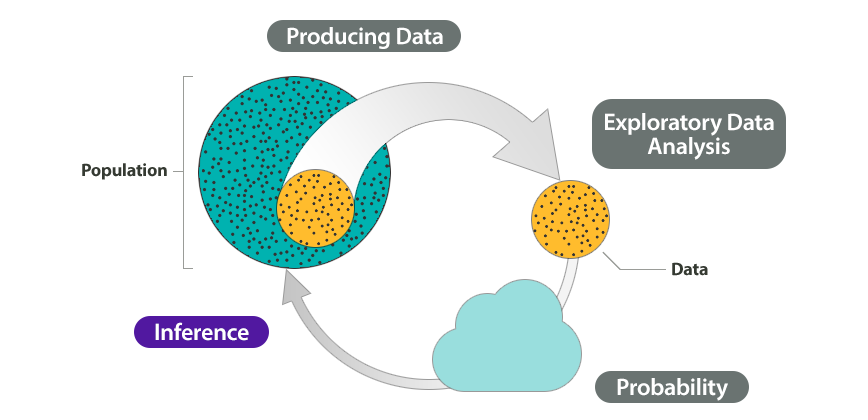

Source: [Lumen learning](https://courses.lumenlearning.com/wm-concepts-statistics/chapter/wim-linking-probability-to-statistical-inference/)

Example:

- Research Question: What percentage of U.S. adults support the death penalty?
- Steps in Statistical Investigation:
  1. Produce Data: Determine what to measure, then collect the data. The poll selected 1,082 U.S. adults at random. Each adult answered this question: “Do you favor or oppose the death penalty for a person convicted of murder?”
  2. Explore the Data: Analyze and summarize the data.In the sample, 65% favored the death penalty.
  3. Draw a Conclusion: Use the data, probability, and statistical inference to draw a conclusion about the population.

  However, there is a cost that has to be taken into account: by drawing a sample we have not observed all of the individuals in the population. It is necessary, then, to account for the uncertainty implied in the sampling process that generated the data. In addition to the **sampling uncertainty**, there are other sources of uncertainty that would lead us to assume our data is generated by a stochastic DGP: **theoretical and fundamental uncertatinty**.

  Let’s consider a scenario where we are not only interested in understanding the percentage of adults who support the death penalty in the U.S. but also whether there is a difference in support based on political affiliation, particularly Republicans. In this case, we have a theoretical framework that focuses on the relationship between a person’s political alignment and their stance on the death penalty. However, it’s possible that other factors, such as how individuals value a person’s life, could also influence their views on the death penalty. Unfortunately, we didn’t include these additional factors in our theory, which could potentially impact our data collection. Consequently, the results derived from our sample data might be subject to theoretical uncertainty. Additionally, there is the possibility of fundamental uncertainty within our sample data. This could arise when respondents pay minimal attention to the survey questions and opt for random responses regarding their opinions on the death penalty. Such factors are beyond the control of researchers and can introduce further uncertainty into our findings.

  In summary, statistical inferences always involve an element of uncertainty. As a researcher, our aim is to account for this uncertainty by incorporating probability statements as an integral part of our conclusions in our findings.
2. Probability Distribution

   How to model stochastic data generating process? Any time we want to answer a research question that involves using a sample to draw a conclusion about some larger population, we need to answer the question “how likely is it that we get a sample proportion of people supporting for the death penalty at 65%?” or “what is the probability of…?”. To answer such a question, we need to use probability to quantify the uncertainty of the outcomes of interest.

   Just a reminder, when we employ a probability distribution to model a stochastic DGP, we are essentially playing as the God saying that the data for the variable of interest is generated by this probability distribution. However, in real-life, what we can directly observe is the empirical distribution (or frequency distribution) derived from our available sample data. We make an assumption that this empirical distribution from the sample data reflects the underlying theoretical probability distribution.
   1. Discrete Random Variables
   - What is a Random Variable $X$?

     Given a random experiment with sample space $S$, a random variable $X$ is a set function that assigns one and only one real number to each element $s$ that belongs in the sample space $S$. The set of all possible values of the random variable $X$, denoted $x$, is called the support, or space, of $X$. For example:

     A rat is selected at random from a cage of male ($M$) and female rats ($F$). Once selected, the gender of the selected rat is noted. The sample space is thus:
     $$S = \left \{ M, F \right \}$$

     Let’s further define the random variable $X$ as follows:
     - Let $X = 0$ if the rat is male.
     - Let $X = 1$ if the rat is female.

     Note that the random variable $X$ assigns one and only one real number (0 and 1) to each element of the sample space ($M$ and $F$). The support, or space, of $X$ is $\left \{ 0, 1 \right \}$.

     Also note that we don’t necessarily need to use the number 0 and 1 as the support. For example, we could have alternatively (and perhaps arbitrarily) used the numbers 5 and 15, respectively. In that case, our random variable would be defined as $X = 5$ of the rate is male, and $X = 15$ of the rate is female.
   - What is the Probability Mass Function (PMF) of a discrete random variable?

     The probability that a discrete random variable $X$ takes on a particular value $x$, that is, $P(X = x)$, is frequently denoted $f(x)$. The function $f(x)$ is typically called the **probability mass function (PMF)**.

     The probability mass function, $P(X = x) = f(x)$, of a discrete random variable $X$ is a function that satisfies the following properties:
     - $P(X = x) = f(x) > 0$ if $x \in$ the support $S$

       For every element in the support $S$, all of the probabilities must be positive. Note that if $x$ does not belong in the support $S$, then $f(x) = 0$.
     - $\sum_{x \in S}^{}f(x)=1$

       If you add up the probabilities for all of the possible $x$ values in the support $S$, then the sum must equal 1.
     - $P(X \in A) = \sum_{x \in A}^{}f(x)$

       To determine the probability associated with the event $A$, you just sum up the probabilities of the $x$ values in $A$.

     **Exercise 1**:

     I toss a fair four-sided dice, and let $X$ be defined as the outcome on the die I observe, $\left \{ 1, 2, 3, 4 \right \}$. What is the sample space of $X$, the possible outcomes of $X$, as well as its probability mass function $f(x)$?

     We can also plot PMF in R.

     ```r
     x <- 1:4
     n <- length(x)
     fx <- rep(1/4, n)
     ```

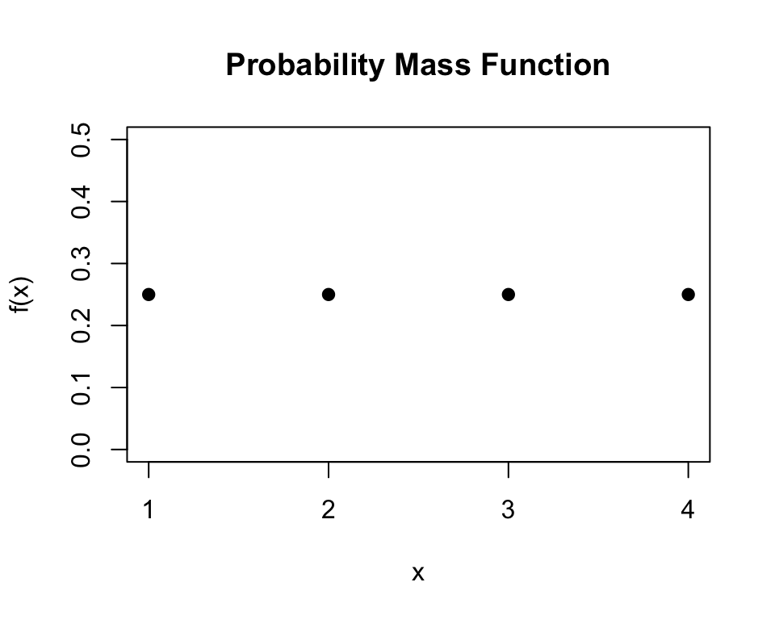

     ```r
     plot(x = x, y = fx, pch = 19,
         xaxt="n",
         ylim = c(0, 0.5),
         xlab = "x",
         ylab = "f(x)",
         main = "Probability Mass Function")
     axis(1, at = seq(min(x), max(x), by = 1))
     ```

   - What is the Cumulative Distribution Function (CDF) of a discrete random variable?

     The cumulative distribution function (CDF) of the discrete random variable $X$ has the following definition:

     $$F(x) = P(X \leq x) = \sum_{a \leq
     x}^{}f(a)$$

     in which $F(x)$ is a non-decreasing *step* function.

     We can also plot CDF in R. Let’s plot the CDF of the Exercise 1.

     ```r
     x <- 1:4
     n <- length(x)
     fx <- rep(1/4, n)
     Fx <- cumsum(fx)
     ```

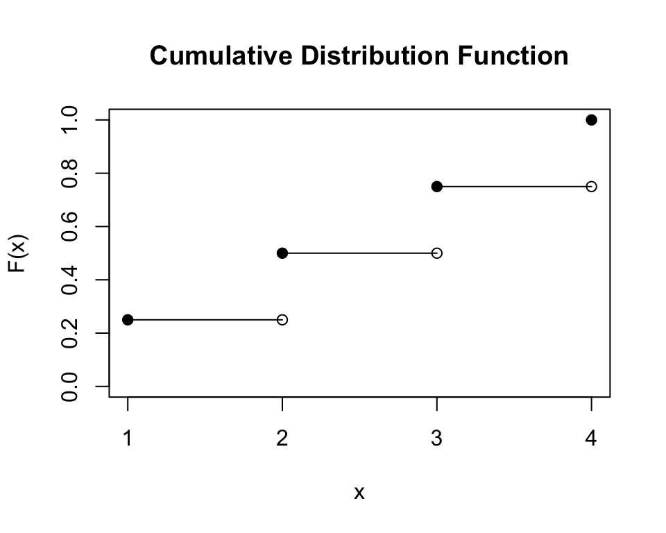

     ```r
     ## Let's make an empty plot
     plot(x = NA, y = NA, pch = NA,
         xaxt="n",
         xlim = c(min(x), max(x)),
         ylim = c(0, 1),
         xlab = "x",
         ylab = "F(x)",
         main = "Cumulative Distribution Function")
     axis(1, at = seq(min(x), max(x), by = 1))

     ## Add closed circles, open circles, and finally the horizontal lines
     points(x = x, y = Fx, pch = 19) ## closed circles
     points(x = x[-1], y = Fx[-n], pch = 1) ## open circles
     for(i in 1:(n-1)) {
       points(x = x[i+0:1],
              y = Fx[c(i,i)],
              type = "l")
      }
     ```

     **Exercise 2**:

     Suppose $X$ is a discrete random variable. Let the PMF of $X$ be equal to:

     $$f(x) = \frac{5-x}{10}, x = 1, 2, 3, 4.$$

     The CDF of $X$ is $F(x) = P(X \leq x) = \sum_{a \leq x}^{}f(a)$.

     **2.1** What is the cumulative probability when $X \leq 2$?

     **2.2** Is $P(X \leq 2)$ equal to $P(X = 2)$?
   2. Continuous Random Variables

      A continuous random variable takes on an uncountably infinite number of possible values. For a discrete random variable $X$ that takes on a finite or countably infinite number of possible values, we determined $P(X=x)$ for all of the possible values of $X$, and called it the probability mass function (PMF).

      For continuous random variables, the probability that $X$ takes on any particular value $x$ is 0. That is, finding $P(X=x)$ for a continuous random variable $X$ is not going to work. Instead, we’ll need to find the probability that $X$ falls in some interval $(a, b)$, that is, we’ll need to find $P(a<X<b)$. We’ll do that using a **probability density function (PDF)**.
   - What is the Probability Density Function (PDF) of a continuous random variable?

     The probability density function of a continous random variable $X$ with support $S$ is an integrable function $f(x)$ satisfying the following:
     1. $f(x)$ is positive everywhere in the support $S$, that is, $f(x)>0$, for all $x$ in $S$.
     2. The area under the curve f(x) in the support $S$ is 1, that is:

        $$\int_{S}^{}f(x)dx=1$$
     3. If $f(x)$ is the PDF of $x$, then the probability that $X$ belongs to $A$, where $A$ is some interval, is given by the integral of $f(x)$ over that interval, that is:

        $$P(X \in A) =
        \int_{A}^{}f(x)dx$$

     As you can see, the definition for the PDF of a continuous random variable differs from the definition for the PMF of a discrete random variable by simply changing the summations that appeared in the discrete case to integrals in the continuous case.

     **Exercise 3**:

     Let $X$ be a continuous random variable whose PDF is:

     $f(x) = 3x^2$, $0<x<1$

     First, note again that $f(x) \neq P(X=x)$. For example, $f(0.9)=3(0.9)^{2}=2.43$, which is clearly not a probability! In the continuous case, $f(x)$ is instead the height of the curve at $X=x$, so that the total area under the curve is 1. In the continuous case, it is areas under the curves that define the probabilities.

     Now let’s first start by verifying that $f(x)$ is a valid probability density function.
     - $f(x) > 0$ at any value of $x$.
     - $\int_{0}^{1}3x^2dx=x^3 |_{x=0}^{x=1}=1^3-0^3=1$

     **3.1** What is the probability that $X$ falls between $\frac{1}{2}$ and 1? That is, what is $P(\frac{1}{2}<X<1)$?

     **3.2** Please use integration to show that $P(X=\frac{1}{2})=0$.

     **Exercise 4**:

     Let $X$ be a continuous random variable whose probability density function is:

     $$f(x) = \frac{x^3}{4}$$

     for any interval $0<x<c$. What is the value of the constant $c$ that makes $f(x)$ a valid probability density function?
   - What is the Cumulative Distribution Function (CDF) of a continuous random variable?

     You might recall that the cumulative distribution function is defined for discrete random variables as:

     $$F(x) = P(X \leq x) = \sum_{a \leq
     x}^{}f(a)$$

     Again, $F(x)$ accumulates all of the probability less than or equal to $x$.The cumulative distribution function for continuous random variables is just a straightforward extension of that of the discrete case. All we need to do is replace the summation with an integral.

     The cumulative distribution function of a continuous random variable $X$ is defined as:

     $$F(x) = P(X \leq x) = \int_{a \leq
     x}^{}f(a)da$$

     Recall that for discrete random variables, $F(x)$ is in general a non-decreasing *step* function. For continuous random variables, $F(x)$ is a non-decreasing *continuous* function.

     **Exercise 5**:

     Let’s return to the example in which $X$ has the following probability density function:

     $f(x) = 3x^2$, $0<x<1$

     What is the cumulative distribution function $F(x)$?
3. Multivariate Probability Distributions

   Now we know the probability distribution of both discrete and continuous random variables, respectively. Let’s extend the concept of a probability distribution of one random variable $X$ to a joint probability distribution of two discrete random variables $X$ and $Y$. For example, suppose $X$ denotes the number of significant others a randomly selected person has, and $Y$ denotes the number of arguments the person has each week. We might want to know if there is a relationship between $X$ and $Y$. Or, we might want to know the probability that $X$ takes on a particular value $x$ and $Y$ takes on a particular value $y$. That is, we might want to know $P(X=x, Y=y)$.

   Suppose we toss a pair of fair, four-sided dice, in which one the dice is red and the other is black. We’ll let:
   - $X$ = the outcome on the red die = $\left \{ 1, 2, 3, 4 \right \}$
   - $Y$ = the outcome on the black die = $\left \{ 1, 2, 3, 4 \right \}$

   What is the support of $f(x, y)$? What is the probability that $X$ takes on a particular value $x$, and $Y$ takes on a particular value $y$? That is, what is $P(X=x, Y=y)$? Please calculate the probability for each cell in the table below. Note that columns represent the outcomes of the black die, whereas rows represent the outcomes of the red die.

   | $f(x,y)$ | $Y=1$ | $Y=2$ | $Y=3$ | $Y=4$ | $f_X(x)$ |
   | --- | --- | --- | --- | --- | --- |
   | $X=1$ |  |  |  |  |  |
   | $X=2$ |  |  |  |  |  |
   | $X=3$ |  |  |  |  |  |
   | $X=4$ |  |  |  |  |  |
   | $f_Y(y)$ |  |  |  |  |  |

   Now that we’ve found our first joint probability mass function, let’s formally define it now.

   Let $X$ and $Y$ be two discrete random variables, and let $S$ denote the two-dimensional support of $X$ and $Y$. Then, the function $f(x, y) = P(X=x, Y=y)$ is a joint probability mass function if it satisfies the following three conditions:
   1. $0 \leq f(x, y) \leq 1$

      Each probability must be a valid probability number between 0 and 1 (inclusive).
   2. $\sum_{}^{}\sum_{(x, y) \in S}^{}f(x, y)=1$

      The sum of the probabilities over the entire support $S$ must equal 1.
   3. $P[(X, Y)\in A]=\sum_{}^{}\sum_{(x, y)\in A}^{}f(x, y)$ where $A$ is a subset of $S$

      In order to determine the probability of an event $A$, you simply sum up the probabilities of the $(x, y)$ values in $A$.
4. Marginal Distribution

   Now, if you take a look back at the representation of our joint p.m.f. in tabular form, you can see that the last column contains the probability mass function of $X$ alone, and the last row contains the probability mass function of $Y$ alone. Those two functions, $f(x)$ and $f(y)$, which in this setting are typically referred to as **marginal probability mass functions**, are obtained by simply summing the probabilities over the support of the other variable. That is, to find the probability mass function of $X$, we sum, for each $x$, the probabilities when $y=1, 2, 3, $ and $4$. That is, for each $x$, we sum $f(x, 1)$, $f(x, 2)$, $f(x, 3)$, and $f(x, 4)$. Now that we’ve seen the two marginal probability mass functions in our example, let’s give a formal definition of a marginal probability mass function.

   Let $X$ be a discrete random variable with support $S_1$, and let $Y$ be a discrete random variable with support $S_2$, Let $X$ and $Y$ have the joint probability mass function $f(x, y)$ with support $S$. Then, the probability mass function of $X$ alone, which is called the marginal probability mass function of $X$, is defined by:

   $$f_X(x)=\sum{y}{}f(x, y)=P(X=x)$$
   $$x \in S_1$$

   where, for each $x$ in the support $S_1$, the summation is taken over all possible values of $y$. Similarly, the probability mass function of $Y$ alone, which is called the marginal probability mass function of $Y$, is defined by:

   $$f_Y(y)=\sum{x}{}f(x, y)=P(Y=y)$$
   $$x \in S_2$$

   where, for each $y$ in the support $S_2$, the summation is taken over all possible values of $x$.

   If you again take a look back at the representation of our joint p.m.f. in tabular form, you might notice that the following holds true:

   $$P(X=x, Y=y) = \frac{1}{16} = P(X=x)
   \cdot P(Y=y) = \frac{1}{4} \cdot \frac{1}{4} = \frac{1}{16}$$

   for all $x \in S_1$, $y \in S_2$. When this happens, we say that $X$ and $Y$ are independent. A formal definition of the independence of two random variables $X$ and $Y$ follows.

   The random variables $X$ and $Y$ are independent if and only if:

   $$P(X=x, Y=y) = P(X=x) \times
   P(Y=y)$$

   for all $x \in S_1$, $y \in S_2$. Otherwise, $X$ and $Y$ are said to be dependent.

   **Exercise 6**:

   Please find the marginal distributions of $X$ and $Y$, respectively.

   | $f(x, y)$ | $X=0$ | $X=1$ | $X=2$ | $f_Y(y)$ |
   | --- | --- | --- | --- | --- |
   | $Y=1$ | $0.1$ | $0.2$ | $0.3$ |  |
   | $Y=2$ | $0.05$ | $0.15$ | $0.2$ |  |
   | $f_X(x)$ |  |  |  |  |

   Is $X$ and $Y$ independent from each other or not?
5. Conditional Distribution

   Marginal distributions tell us the distribution of a particular variable ignoring the other variable(s). In contrast, the conditional distribution of $X$ given $Y$ gives you a distribution over $X$ when holding $Y$ fixed at specific values. Formally:

   $$f_{X|Y}(x|y)=\frac{f(x,
   y)}{f_Y(y)}$$

   The conditional distribution of $Y$ given $X$ is defined by:

   $$f_{Y|X}(y|x)=\frac{f(x,
   y)}{f_X(x)}$$

   Recall the example we had for joint distribution.

   What is the conditional distribution of $Y$ given $X=2$?

   When $Y=1$: $f_{Y|X}(y|x=2)=\frac{f(x, y)}{f_X(x=2)}=\frac{\frac{1}{16}}{\frac{4}{16}}=\frac{1}{4}$

   When $Y=2$: $f_{Y|X}(y|x=2)=\frac{f(x, y)}{f_X(x=2)}=\frac{\frac{1}{16}}{\frac{4}{16}}=\frac{1}{4}$

   When $Y=3$: $f_{Y|X}(y|x=2)=\frac{f(x, y)}{f_X(x=2)}=\frac{\frac{1}{16}}{\frac{4}{16}}=\frac{1}{4}$

   When $Y=4$: $f_{Y|X}(y|x=2)=\frac{f(x, y)}{f_X(x=2)}=\frac{\frac{1}{16}}{\frac{4}{16}}=\frac{1}{4}$

   So,

   $f_{Y|X}(y|x=2)= \frac{1}{4} if y = 1, 2, 3, 4$

   We will get the same answers for the conditional probability of $Y$ given $X=1$, $X=3$, or $X=4$.

   From this example of finding the conditional probability of $Y$ given $X=2$, we again find that $X$ and $Y$ are independent from each other, as the distribution over $Y$ does not change as $Y$ changes. That is,

   $$f(x, y) = f_X(x)\cdot f_Y(y) \Rightarrow
   f_{X|Y}{x|y} = f_X(x) and f_{Y|X}{y|x} = f_Y(y)$$

   **Exercise 7**:

   Find the conditional distribution of $X$ given $Y=2$.

   | $f(x, y)$ | $X=0$ | $X=1$ | $X=2$ | $f_Y(y)$ |
   | --- | --- | --- | --- | --- |
   | $Y=1$ | $0.1$ | $0.2$ | $0.3$ | $0.6$ |
   | $Y=2$ | $0.05$ | $0.15$ | $0.2$ | $0.4$ |
   | $f_X(x)$ | $0.15$ | $0.35$ | $0.5$ | $1$ |

6. Central Tendency of Probability Distributions

   The expected value, or mathematical expectation, of a discrete random variable $X$ is:

   $$E(X)=\sum_{x\in X}{}xf(x)$$

   where $x$ is the possible outcomes of the discrete random variable $X$, and $f(x)$ is the probability mass function of $X$.

   For example, what is the average toss of a fair six-sided die?

   If the random variable $X$ is the top face of a tossed, fair, six-sided die, then the PMF of $X$ is:

   $$f(x) = \frac{1}{6}$$

   for $x = 1, 2, 3, 4, 5,$ and $6$. Therefore, the average toss, that is the expected value of $X$, is:

   $$E(X) = 1(\frac{1}{6}) + 2(\frac{1}{6}) +
   3(\frac{1}{6}) + 4(\frac{1}{6}) + 5(\frac{1}{6}) + 6(\frac{1}{6}) =
   3.5$$

   Hmm… if we toss a fair, six-sided die once, should we expect the toss to be 3.5? No, of course not! All the expected value tells us is what we would expect the average of a large number of tosses to be **in the long run**. If we toss a fair, six-sided die a thousand times, say, and calculate the average of the tosses, will the average of the 1000 tosses be exactly 3.5? No, probably not! But, we can certainly expect it to be close to 3.5. It is important to keep in mind that the expected value of is a theoretical average, not an actual, realized one! Let’s run a simulation to observe this more directly.

   ```r
   x <- 1:6

   s1 <- sample(x, replace = TRUE, size = 100)
   mean(s1)
   ```

   ```
   ## [1] 3.25
   ```

   ```r
   s2 <- sample(x, replace = TRUE, size = 1000)
   mean(s2)
   ```

   ```
   ## [1] 3.45
   ```

   ```r
   s3 <- sample(x, replace = TRUE, size = 10000)
   mean(s3)
   ```

   ```
   ## [1] 3.508
   ```

   Expectations have some nice properties:
   1. The expected value of a constant $a$ is that constant: $E(a) = a$.
   2. The expected value of a constant $b$ times a random variable $X$ is that constant times the expected value of $X$: $E(bX) = bE(X)$.
   3. Given two random variables, $X$ and $Y$, $E(X+Y) = E(X) + E(Y)$.
   4. $E(X)$ always falls between the minimum and maximum values that $X$ can take: $min X \leq E(X) \leq max X$.

   **Exercise 8**:

   Suppose the PMF of the discrete random variable $X$ is:

   | $x$ | $0$ | $1$ | $2$ | $3$ |
   | --- | --- | --- | --- | --- |
   | $f(x)$ | $0.2$ | $0.1$ | $0.4$ | $0.3$ |

   8.1 What is the expected value of $X$, that is, $E(X)$?

   8.2 Suppose that there is another discrete random variable $Y$, and the expected value of $Y$ is $3.2$, that is, $E(Y) = 3.2$. What is the expected value of $2X+3Y$, that is, $E(2X+3Y)$?

   **Exercise 9**:

   9.1 Find the expected values of the random variables from their marginal distributions.

   9.2 Find the expected value of $X$ given $Y=2$.

   | $f(x, y)$ | $X=0$ | $X=1$ | $X=2$ | $f_Y(y)$ |
   | --- | --- | --- | --- | --- |
   | $Y=1$ | $0.1$ | $0.2$ | $0.3$ | $0.6$ |
   | $Y=2$ | $0.05$ | $0.15$ | $0.2$ | $0.4$ |
   | $f_X(x)$ | $0.15$ | $0.35$ | $0.5$ | $1$ |

   All these nice properties can also be applied to a continuous random variable. The expected value of a continuous random variable is:

   $$\int_{x\in X}{}xf(x)dx$$

   Let’s use an example to practice. Let the random variable $X$ denote the time a person waits for an elevator to arrive. Suppose the longest one would need to wait for the elevator is 2 minutes, so that the possible values of $X$ (in minutes) are given by the interval $[0,2]$. A possible PDF for $X$ is given by:

   $$f(x) = \begin{cases} x, & \text{for
   } 0 < x \leq 1\\ 2-x, & \text{for } 1 < x \leq 2 \\ 0, &
   \text{otherwise } \end{cases}$$
   What is the expected value of $X$?

   $$E(X) = \int_{0}^{1}x\cdot xdx +
   \int_{1}^{2}x\cdot(2-x)dx = \int_{0}^{1}x^2dx + \int_{1}^{2}(2x-x^2)dx =
   \frac{1}{3} + \frac{2}{3} = 1$$

   Thus, we expect a person will wait 1 minute for the elevator on average.
7. Dispersion of Probability Distributions

   The variance of a random variable $X$ is:

   $$Var(X) = E((X-E(X))^2) = E(X^2) -
   E(X)^2$$

   The formulat can be applied to both discrete and continuous random variables.

   The variance of a random variable also has nice properties:
   1. The variance of a constant $a$ is $0$: $Var(a) = 0$.
   2. $Var(X)$ is always weakly positive: $Var(X) \geq 0$.
   3. The variance of a constant $b$ times a random variable $X$ is that constant squared times the variance of $X$: $Var(bX) = b^2 Var(X)$.
   4. If $X$ and $Y$ are stochastically independent, then $Var(X+Y) = Var(X) + Var(Y)$.

   **Exercise 10**:

   10.1 What is the variance of $X$? 10.2 What is Var(2X)?

   | $x$ | $0$ | $1$ | $2$ | $3$ |
   | --- | --- | --- | --- | --- |
   | $f(x)$ | $0.2$ | $0.1$ | $0.4$ | $0.3$ |

   **Exercise 11**:

   Recall the elevator question, please compute the variance of $X$.

   $$f(x) = \begin{cases} x, & \text{for
   } 0 < x \leq 1\\ 2-x, & \text{for } 1 < x \leq 2 \\ 0, &
   \text{otherwise } \end{cases}$$